# Estudo para a precificação de ativos relacionados ao setor da Tecnologia da Informação utilizando o Capital Asset Pricing Model

## Programa de Pós-Graduação em Pesquisa Operacional Unifesp / ITA

## Modelagem de Investimentos e Riscos (PO-215)

Aluno: Paulo Giovani de Faria Zeferino  
Professor: Dr. Renato Cesar Sato

# Resumo

Este trabalho foi desenvolvido como requisito final para a disciplina de Modelagem de Investimentos e Riscos, com o objetivo de apresentar os resultados de um estudo sobre a precificação de ativos do portfólio de ações em uma carteira de investimentos. Para isso, utilizou-se o modelo de precificação de ativos conhecido na literatura financeira como Capital Asset Pricing Model (CAPM). Baseado em dados obtidos por meio da plataforma Yahoo! Finance, abrangendo um período entre os anos de 2018 e 2023, foi selecionado uma amostra representativa contendo o preço de fechamento de 10 empresas atuantes no segmento de Infraestrutura de Software. Após a realização de uma análise exploratória dos dados dessa amostra, aplicou-se o modelo CAPM para identificar os riscos que potenciais investidores poderiam enfrentar. Por fim, calculou-se o retorno esperado para o portfólio de ações de uma carteira de investimentos composta pelos ativos escolhidos, considerando o índice Standard and Poor's 500.

**Palavras-chave**: Modelo de Precificação de Ativos, CAPM, Standard and Poor's 500, Tecnologia da Informação, Infraestrutura de Software.

# 1. Introdução

O mercado financeiro é um ambiente complexo e dinâmico onde ocorre a negociação de uma ampla variedade de ativos, como ações, opções, títulos, moedas estrangeiras e commodities. Diferentes instituições desempenham papéis cruciais ao facilitar o encontro entre compradores e vendedores, além de regulamentar e fiscalizar as transações, garantindo a segurança e a transparência do mercado. Dentro desse contexto, os investidores desempenham um papel fundamental. Eles são aqueles que possuem recursos financeiros disponíveis e buscam aumentar seu patrimônio. De acordo com Gomes (2020) [1], os investidores têm diversas opções para alcançar esse objetivo, porém todos eles compartilham uma premissa comum: a alocação de seus recursos em investimentos que apresentam potencial de valorização, de acordo com suas diretrizes e estratégias.

Um dos mercados mais relevantes é o mercado de ações, onde ocorre a negociação de títulos que representam a propriedade de uma empresa. Esse mercado desempenha um papel crucial na economia, pois viabiliza o financiamento das empresas por meio da emissão de ações. Ao emitir ações, as empresas têm a oportunidade de captar recursos junto aos investidores, possibilitando o financiamento de projetos, expansões e pesquisas. Isso impulsiona o crescimento econômico, gera empregos e promove a inovação. Segundo Soranco et al. (2014) [2], o preço das ações é influenciado por uma série de fatores, tanto internos quanto externos. Os fatores internos estão relacionados ao desempenho da empresa emissora das ações, como seus resultados financeiros, estratégias de negócios, governança corporativa e capacidade de inovação. Por outro lado, os fatores externos são influenciados pelo ambiente econômico em que a empresa opera, incluindo a saúde da economia nacional, políticas governamentais, flutuações cambiais e as expectativas dos agentes econômicos.

Uma carteira de investimentos bem estruturada é uma combinação cuidadosamente planejada de diversos ativos financeiros. Ela busca maximizar os retornos financeiros e gerenciar os riscos por meio da diversificação. A construção da carteira envolve a seleção criteriosa de ativos, considerando o perfil de risco do investidor, seus objetivos financeiros, horizonte de investimento e tolerância ao risco. A compreensão dos métodos de avaliação de riscos é de extrema relevância para os investidores. Esses métodos permitem estimar o valor teórico de uma ação e prever seu potencial de retorno. Ao utilizar esses métodos, os investidores têm subsídios valiosos para tomar decisões embasadas sobre a compra ou venda de ativos, o que auxilia na composição de sua carteira de investimentos.

A precificação de ativos desempenha um papel fundamental na gestão eficiente e eficaz de uma carteira de investimentos. Ela envolve uma avaliação sistemática do valor de cada ativo, permitindo aos investidores tomar decisões embasadas sobre alocação de recursos, identificar oportunidades de investimento e gerenciar os riscos associados. Uma carteira bem precificada reflete a compreensão dos investidores sobre o potencial de retorno e risco de cada ativo individual, assim como a interação entre eles.

Uma das abordagens mais comuns para a precificação de ativos é a utilização de modelos de avaliação, como por exemplo, o Modelo de Precificação de Ativos de Capital, conhecido na literatura como CAPM (*Capital Asset Pricing Model*). Desenvolvido por Willian Sharpe, o CAPM é considerado teoricamente uma das melhores alternativas para a apuração da taxa de retorno requerida pelos investidores [3].

Nesse contexto, o presente trabalho tem por objetivo realizar um estudo sobre a precificação de ativos em uma carteira de investimentos, por meio da utilização do modelo CAPM. Toda a codificação foi realizada utilizando-se a linguagem de programação *Python* e o ambiente do *Jupyter Notebook*. Os arquivos do projeto podem ser acessados no seguinte repositório: https://github.com/PauloGiovani/CAPM. O resultado obtido é apresentado de maneira estruturada, dentro das seguintes seções: *Introdução*, *Revisão da Literatura*, *Materiais e Dados Utilizados*, *Resultados*, *Discussão e Limitações da Pesquisa*.

# 2. Revisão da Literatura

Esta seção tem por objetivo abordar as referências relacionadas ao tema estudado, transcrevendo conceitos a respeito dos cálculos utilizados para avaliar o risco e retorno dos ativos estudados, com base no modelo CAPM.

## 2.1 A Importância de Investir

Aprender a investir é uma prática fundamental para construir um futuro financeiramente seguro e alcançar objetivos de longo prazo. Existem várias razões pelas quais investir é crucial. Em primeiro lugar, o investimento permite o crescimento do patrimônio ao longo do tempo. Ao destinar recursos para ativos que têm potencial de valorização, como ações, imóveis ou fundos de investimento, é possível obter retornos financeiros significativos no futuro. Dessa forma, o investimento se torna uma maneira de aumentar a renda e alcançar a independência financeira.

## 2.2 O Portfólio de Ações

A bolsa de valores é o mercado organizado onde se negociam ações de sociedades de capital aberto (públicas ou privadas) e outros valores mobiliários. Ela funciona como um lugar seguro em que pessoas e empresas podem fazer negociações online. As empresas vendem parte de seu negócio, na forma de ações, sendo que as pessoas interessadas podem comprá-las e vendê-las entre si para obter lucro [4].

Para Assaf Neto (2003) [5], as ações representam a menor fração do capital social de uma empresa. O acionista é considerado um coproprietário da companhia com direito a participação em seus resultados. Elas podem ser emitidas em forma de cautelas ou certificados ou do tipo escritural, sendo seu controle feito a partir de contas de depósitos em nome de seus titulares em uma instituição depositária.

O portfólio de ações é composto pelos ativos que integram a carteira de investimentos. A seleção adequada no contexto de um portfólio é fundamental e supera a importância das ações individuais. Afinal, conforme citado por Reis (2022) [6], é por meio dele que se determina o resultado final do investidor, levando em consideração o equilíbrio, diversificação e gestão dos diferentes ativos.

Um portfólio de ações é formado pela cuidadosa seleção de ativos que comporão a carteira do investidor. No entanto, é importante destacar que o portfólio de ações é apenas uma parte do processo de construção de uma carteira de investimentos, que pode abranger diversas outras classes de ativos, como títulos públicos, fundos imobiliários, dívida privada e outros. A construção de uma carteira diversificada, que contempla diferentes tipos de investimentos, permite uma gestão mais ampla e equilibrada dos riscos e oportunidades. A Figura 1 exibe um exemplo de uma carteira de investimentos considerada mais agressiva, onde a maior parte do capital investido foi alocada nos ativos de renda variável.

[figure not shown]

**Figura 1**: Exemplo de uma carteira de investimentos agressiva. Fonte: Reis (2023) [7].

Diversos estudos têm apontado que o número ideal de ativos para uma carteira de ações de longo prazo geralmente varia entre 10 e 20 [6]. Isso ocorre porque, a partir de um certo número de ações, as adições adicionais ao portfólio não contribuem significativamente para a diversificação, conforme evidenciado em comparações de portfólios de ações. Nos investimentos, o conceito de desvio padrão, considerado uma medida de diversificação, desempenha um papel importante. Quanto menor o desvio padrão, maior a diversificação do portfólio. Estudos de análise de risco indicam que, a partir de cerca de 10 empresas, o desvio padrão apresenta pouca redução com a adição de novas ações. Portanto, considera-se que o número ideal de empresas para um portfólio esteja situado entre 10 e 20, buscando um equilíbrio entre diversificação e gerenciamento eficiente dos ativos.

## 2.3 Precificação de Ativos

A precificação de ativos de capital é um processo essencial no campo das finanças, utilizado para determinar o valor justo de investimentos e ativos financeiros. Essa prática desempenha um papel crucial em diversas áreas, como mercados de ações, títulos, imóveis e outros ativos de investimento. Esse processo envolve a avaliação do valor intrínseco de um ativo, ou seja, o valor que reflete suas características e benefícios subjacentes. Esse valor pode ser calculado com base em uma série de fatores, como fluxos de caixa futuros esperados, risco associado ao investimento, taxas de juros e condições econômicas gerais.

Uma das abordagens mais comuns na precificação de ativos de capital é a utilização de modelos de avaliação, como o modelo CAPM, utilizado neste trabalho. Esse modelo considera o risco sistemático de um ativo, medido pelo índice *Beta*, além do prêmio de risco de mercado e a taxa livre de risco para determinar o retorno esperado desse ativo.

## 2.4 O Índice S&P 500

O índice S&P 500, ou Standard & Poor's 500, é um dos principais indicadores do mercado financeiro global, representando o desempenho das 500 maiores empresas listadas nas bolsas de valores dos Estados Unidos. Essas empresas são selecionadas com base em critérios como tamanho de mercado, liquidez e representatividade do setor [8]. O S&P 500 oferece uma visão abrangente do setor corporativo dos Estados Unidos e é amplamente utilizado como referência por investidores e profissionais do mercado financeiro em todo o mundo.

Criado pela agência de classificação de risco Standard & Poor's em 1957, o S&P 500 abrange empresas de diversos setores, incluindo tecnologia, finanças, saúde, energia, consumo e indústria [9]. A seleção das empresas que compõem o índice é baseada em critérios rigorosos, como tamanho de mercado, liquidez e importância do setor. Além disso, o peso de cada empresa no índice é determinado pelo seu valor de mercado, ou seja, as empresas com maior capitalização têm maior influência no movimento geral do índice. Isso significa que o desempenho das grandes empresas do mercado, como *Apple*, *Microsoft* e *Amazon*, por exemplo, têm um impacto significativo no comportamento do índice como um todo. Acompanhando o S&P 500, os investidores podem avaliar o desempenho de seus próprios investimentos, compará-los com o retorno do índice e tomar decisões embasadas em seus negócios.

## 2.5 Tipos de Retorno

Segundo Gitman et al. (2010) [10], O retorno representa o lucro ou prejuízo obtido por um investimento em um determinado período. Ele é calculado somando os proventos em dinheiro recebidos e a variação de valor do ativo durante o mesmo período, podendo ser expresso em termos absolutos ou em porcentagem. O retorno esperado é a estimativa do retorno que um indivíduo espera obter de uma ação no próximo período, conforme definição dada por Ross et al. (2015) [11]. Por ser uma expectativa, é importante ressaltar que o retorno efetivo pode ser maior ou menor do que o esperado. Essa expectativa pode se basear no desempenho histórico da ação, como o retorno médio obtido em períodos passados.

## 2.6 Risco

O risco é uma característica inerente às operações no mercado de ações e influencia os retornos. Para Mellagi Filho e Ishikawa (2007) [12], ele é composto por uma série de fatores, tanto internos quanto externos, que exercem influência sobre o preço dos ativos, especialmente ações. Para compreender e mensurar esses diversos fatores, é fundamental ter familiaridade com métodos estatísticos para avaliação do risco nos investimentos. Brigham e Ehrhardt (2006) [13] afirmam que a avaliação do risco de um ativo pode ser realizada de duas maneiras: de forma isolada, na qual os ativos são analisados individualmente, ou como parte de uma carteira, na qual os ativos são combinados e avaliados conjuntamente.

## 2.7 Yahoo! Finance

O *Yahoo! Finance* é uma plataforma online que oferece uma ampla gama de informações e serviços relacionados ao mercado financeiro. Lançado em 1994, tornou-se uma referência popular para investidores, profissionais do mercado financeiro e entusiastas interessados em acompanhar notícias, dados financeiros e análises sobre empresas, ações, índices e outros instrumentos financeiros [14].

Uma das principais características do *Yahoo! Finance* é a sua extensa cobertura de dados e informações financeiras em tempo real. Os usuários podem acessar cotações atualizadas de ações, índices de mercado, moedas, *commodities* e outros ativos financeiros. Além disso, a plataforma oferece gráficos interativos, históricos de preços, informações sobre dividendos, relatórios financeiros e outras métricas úteis para análise e acompanhamento dos mercados.

## 2.8 Modelo de Precificação de Ativos - CAPM

Mensurar o risco não é uma tarefa trivial. O cálculo do risco requer conhecimento da teoria da probabilidade e compreensão de como os riscos e retornos dos ativos se comportam dentro de um modelo adequado. Conforme citado por Farias, Moura e Figueiredo (2017) [15], um dos modelos mais bem-sucedidos para mensurar o risco é conhecido como Modelo de Precificação de Ativos de Capital (CAPM - *Capital Asset Pricing Model*).

O trabalho clássico de Markowitz (1959), em que o retorno foi estudado como a diferença de log dos preços, permitiu o desenvolvimento do Modelo CAPM por Sharpe (1963 e 1964), o qual apresentou o cálculo do retorno na forma linear, e contou ainda com as contribuições de Tobin (1958), Treynor (1961), Lintner (1965), Mossin (1966) e Black (1972) para o aperfeiçoamento do modelo, considerando haver um relacionamento linear entre risco (variância do retorno) e retorno (média da rentabilidade ou recompensa do ativo). Para Araújo, do Carmo Oliveira e Silva (2012) [16], essa teoria de precificação de ativos teve tamanha importância para o campo das finanças modernas, que Sharpe foi laureado com o Prêmio Nobel de Economia em 1990. Essa abordagem auxilia os investidores a tomar decisões informadas sobre o risco e retorno de seus investimentos, contribuindo para uma gestão mais eficiente da carteira.

O modelo estabelece uma relação entre os riscos sistemáticos, ou não diversificáveis, e os retornos esperados de um projeto. Embora seja amplamente utilizado na análise de ativos financeiros, o CAPM também pode ser aplicado na avaliação do risco e retorno de investimentos e ativos empresariais, conforme afirmam Gropelli, Nikbakht e Castro (1998) [17], além de auxiliar na determinação do custo de capital próprio, segundo Martelanc, Pasin e Cavalcante (2005) [18]. O custo de capital é a taxa de retorno mínima necessária para atrair investidores interessados em um determinado projeto ou investimento. Por meio do CAPM, é possível estimar esse custo e avaliar a viabilidade financeira de um empreendimento, contribuindo para uma análise mais precisa e embasada na tomada de decisões de investimento. Ele parte do pressuposto de que o retorno de um ativo é composto por dois componentes: o retorno livre de risco e o prêmio de risco. O retorno livre de risco é o retorno que um investidor pode obter investindo em um ativo sem risco, como títulos do governo. O prêmio de risco é a compensação adicional que um investidor exige para investir em um ativo mais arriscado em relação ao ativo livre de risco.

De acordo com Soranco et al. (2014) [2], o modelo CAPM foi criado baseado nas seguintes hipóteses:

- Os investidores preocupam-se apenas com o valor esperado e com a variância (ou desvio padrão) da taxa de retorno;
- A preferência dos investidores consiste em um retorno maior e risco menor;
- O desejo dos investidores é obter uma carteira eficiente: as que dão o máximo de retorno esperado, dado o risco, ou o mínimo risco, dado o retorno esperado;
- Os investidores estão de acordo quanto às distribuições de probabilidades das taxas de retorno dos ativos, o que possibilita a existência de um único conjunto de carteiras eficiente.

O modelo de determinação do preço dos ativos foi desenvolvido com base em estudos pioneiros de Harry M. Markowitz e William F. Sharpe, e é considerado um dos mais robustos e essenciais para a análise de investimentos. Para Mellagi Filho e Ishikawa (2007) [12], sua premissa fundamental é que um investidor só estará disposto a aplicar em um ativo com risco se o retorno esperado for suficientemente elevado para compensar esse risco. Sob a suposição de que todos os investidores agem dessa maneira e que as oportunidades de arbitragem são esgotadas, observa-se uma relação linear direta entre o retorno médio do mercado e o desvio-padrão (risco). Consequentemente, os ativos com maior retorno tendem a apresentar maior nível de risco, segundo afirma Soranco et al. (2014) [2]. Essa abordagem oferece uma base sólida para a precificação de ativos e auxilia na avaliação dos retornos e riscos associados a diferentes investimentos, permitindo aos investidores tomar decisões embasadas em suas estratégias de investimento.

## 2.8.1 Coeficiente Beta de um Ativo

Para Brigham e Ehrhardt (2006) [13], a principal conclusão do CAPM é que o risco de uma ação individual é a quantia de risco com que o ativo contribui para o risco de uma carteira bem diversificada. Desta maneira, o risco relevante de uma ação individual, chamado de coeficiente *Beta*, é definido pelo CAPM como a quantidade de risco que uma ação contribui para uma carteira de mercado. O *Beta* mede a sensibilidade de uma ação em relação à movimentação da carteira de mercado, conforme afirma Ross et al. (2015) [11]. O seu valor é calculado da seguinte forma:

$$\beta_i = Cov \ (R_i, R_M) \over \sigma^2 (R_M)$$

- $Cov \ (R_i, R_M)$ representa a covariância ente os retornos do ativo *i* da carteira de mercado;
- $\sigma^2 (R_M)$ representa a variância da carteira de mercado.

O índice *Beta* é um dos indicadores mais utilizados para realizar a análise do risco de um portfólio ou de um ativo específico. Muito difundido entre os investidores, principalmente os que fazem uma análise fundamentalista, ele é utilizado como uma representação para uma medida de risco, que mede a sensibilidade entre por exemplo, uma ação e um índice como o S&P 500, conforme cita Scherer (2020) [19]. O índice *Beta* é utilizado para medir a volatilidade de uma ação em comparação com a volatilidade geral do mercado. Na área financeira, a volatilidade é uma medida de dispersão dos retornos de um título ou índice de mercado. Quanto mais o preço de uma ação varia em um período de tempo, maior o risco de se ganhar ou perder dinheiro negociando esta ação. Logo, a volatilidade é uma medida de risco. Portanto, uma vez que sabemos o *Beta* de diversos ativos, é possível compará-los e descobrir quais ativos são mais agressivos e quais são mais defensivos.

De acordo com o CAPM, o coeficiente *Beta* mede o risco sistemático de um ativo em relação ao mercado como um todo. Esse coeficiente representa a inclinação da linha de regressão linear entre o retorno do mercado e o retorno da ação. Um ativo com um *Beta* maior do que 1 é considerado mais arriscado do que o mercado, enquanto um *Beta* menor do que 1 indica um ativo menos arriscado. Valores de *Beta* iguais a 1 indicam que o preço do ativo está fortemente correlacionado com o mercado. A **Tabela 1** exibe o comportamento do ativo em relação aos valores do coeficiente *Beta*.

**Tabela 1**: Comportamento do ativo em relação aos valores de *Beta*. Fonte: Mellagi Filho e Ishikawa (2007) [12].

| Beta (β) | Interpretação |
| --- | --- |
| β = 1 | O ativo possui o mesmo risco que o mercado. Isto é, se o mercado subir 5%, o ativo tenderá a subir 5%. O efeito negativo se dará da mesma maneira. |
| β > 1 | O ativo possui risco maior que o risco do mercado. Isto é, se o mercado subir 5%, o ativo tenderá a subir mais que 5%. O efeito negativo se dará da mesma maneira. |
| β < 1 | O ativo possui risco menor que o risco do mercado. Isto é, se o mercado subir 5%, o ativo tenderá a subir menos que 5%. O efeito negativo se dará de forma análoga. |

Por exemplo, uma ação cujo o valor do coefiente *Beta* seja 1,26 indica que seu preço é 26% mais volátil do que o preço do mercado. O CAPM sugere que o retorno esperado de um ativo é igual ao retorno livre de risco mais um prêmio de risco proporcional ao *Beta* do ativo, que é multiplicado pela diferença entre o retorno esperado do mercado e o retorno livre de risco.

## 2.8.2 Relação entre Risco e Retorno Esperado

O retorno esperado de um ativo deve estar relacionado positivamente com seu risco, conforme afirma Ross et al. (2015) [11]. Todavia, para Soranco et al. (2014) [2], os investidores somente investirão em um ativo com risco somente se seu retorno for suficientemente compensador. O retorno esperado do mercado pode ser apresentado da seguinte forma:

$$R_M = R_F + \text{Prêmio por risco}$$

- $R_M$ representa o retorno esperado do mercado;
- $R_F$ representa a taxa livre de risco.

## 2.9 Cálculo para a Precificação de um Ativo (CAPM)

Após estimar o retorno esperado do mercado como um todo, surge a necessidade de determinar o retorno esperado de um ativo individual. De acordo com Soranco et al. (2014) [2], é amplamente argumentado que o *Beta* de um título é a medida adequada de risco em uma carteira grande e diversificada. Considerando que a maioria dos investidores possui carteiras diversificadas, espera-se que o retorno esperado de um título esteja diretamente relacionado ao seu *Beta*. Os economistas financeiros representam a relação entre retorno e beta por meio da seguinte fórmula:

$$E(R_i) = R_f + \beta_i \times (E(R_m) - R_f)$$

- $E(R_i)$ representa o retorno esperado do ativo;
- $R_f$ representa o retorno livre de risco;
- $\beta_i$ representa o coeficiente *Beta* do ativo, que mede sua sensibilidade em relação ao risco sistemático do mercado;
- $E(R_m)$ representa o retorno esperado do mercado de ações.

Essa fórmula é chamada de Modelo de Precificação de Ativos, ou CAPM. Ela indica que que o retorno esperado de uma ação está linearmente relacionado ao seu *Beta*, ou seja, o retorno esperado de um ativo é igual ao retorno livre de risco somado ao produto entre o coeficiente *Beta* do ativo e a diferença entre o retorno esperado do mercado e o retorno livre de risco.

# 3. Materiais e Dados Utilizados

A seleção das ações para compor a carteira de investimentos foi baseada em uma análise setorial, que tem como objetivo primordial compreender questões que podem impactar o negócio. Essa técnica consiste em um estudo aprofundado do ambiente externo de uma empresa, fornecendo informações valiosas para as equipes internas e embasando decisões estratégicas [20]. Normalmente, essa análise leva em consideração os seguintes aspectos:

- Mercado;
- Concorrência;
- Público-alvo;
- Demanda pelo produto ou serviço.

Nesse sentido, foi realizada uma pesquisa no site da *Yahoo! Finance* [14] para identificar as ações a serem incluídas na carteira de investimentos. No presente estudo, optou-se por selecionar empresas do setor de **Tecnologia da Informação**, mais especificamente no segmento de **Infraestrutura de Software**. Para essa seleção, foram considerados os índices retornados pela *NASDAQ Global Select Market*, *NASDAQ Global Market* e *NASDAQ Capital Market*, conforme demonstrado na Figura 2.

[figure not shown]

**Figura 2**: Seleção do setor das empresas e seu respectivo segmento, utilizando a plataforma Yahoo! Finance.

Do resultado obtido após a aplicação do filtro, foram selecionadas apenas as ações que não possuíam valores ausentes no início do período. Dessa forma, o conjunto de dados foi composto pelas seguintes ações:

1. MSFT: Microsoft Corp.
2. ADBE: Adobe Inc.
3. PANW: Palo Alto Networks Inc.
4. SNPS: Synopsys Inc.
5. FTNT: Fortinet Inc.
6. MDB: MongoDB Inc.
7. VRSN: VeriSign Inc.
8. ZS: Zscaler Inc.
9. SPLK: Splunk Inc.
10. CHKP: Check Point Software Technologies Ltd.
11. AKAM: Akamai Technologies Inc.
12. DOX: Amdocs Limited.
13. GEN: Gen Digital Inc.
14. OKTA: Okta Inc.
15. DBX: Dropbox Inc.
16. FFIV: F5 Inc.
17. SPSC: SPS Commerce Inc.
18. CYBR: CyberArk Software Ltd.
19. NTNX: Nutanix Inc.
20. EEFT: Euronet Worldwide Inc.
21. ALTR: Altair Engineering Inc.
22. FIVN: Five9 Inc.
23. QLYS: Qualys Inc.
24. WIX: Wix.com Ltd.
25. APPN: Appian Corp.
26. VRNS: Varonis Systems Inc.
27. RPD: Rapid7 Inc.
28. ACIW: ACI Worldwide Inc.
29. VRNT: Verint Systems Inc.
30. NTCT: NetScout Systems Inc.
31. CSGS: CSG Systems International Inc.
32. IMXI: International Money Express Inc.
33. RDWR: Radware Ltd.
34. IIIV: i3 Verticals Inc.
35. SCWX: SecureWorks Corp.
36. OSPN: OneSpan Inc.
37. QIWI: QIWI plc.
38. BAND: Bandwidth Inc.
39. TCX: Tucows Inc.
40. PRTH: Priority Technology Holdings Inc.
41. LSAK: Lesaka Technologies Inc.
42. REKR: Rekor Systems Inc.
43. VERI: Veritone Inc.
44. SANG: Sangoma Technologies Corp.
45. PAYS: PaySign Inc.
46. ALLT: Allot Ltd.
47. RVYL: Ryvyl Inc.
48. USIO: Usio Inc.
49. APCX: AppTech Payments Corp.
50. INTZ: Intrusion Inc.
51. BLIN: Bridgeline Digital Inc.
52. CETX: Cemtrex Inc.
53. NXTP: NextPlay Technologies Inc.

Para a análise utilizando o CAPM, foi utilizado o *Standard and Poor’s 500*, conhecido como índice S&P 500. Esse índice representa um conjunto de ações das 500 maiores empresas do mundo, listadas e domiciliadas nas principais Bolsas de Valores dos Estados Unidos. O objetivo do S&P 500 é refletir o desempenho médio das empresas líderes de seus setores em todo o mundo. Para Pinto (2023) [9], ele é amplamente reconhecido como uma medida padrão do mercado de ações norte-americano.

Após a definição das ações que seriam utilizadas, os dados referentes a um período de 5 anos foram obtidos por meio do *Yahoo! Finance*. Esses valores foram importados e salvos em um arquivo no formato CSV, permitindo a realização da análise utilizando o CAPM.

A partir dos dados contidos no arquivo CSV, foi realizado uma seleção aleatória de um subconjunto contendo informações sobre 10 possíveis ações que poderiam ser incluídas em uma carteira de investimentos. O *ticker* do S&P 500 e seus valores foram adicionados à última coluna desse subconjunto, que foi renomeada de "^GSPC" para "SP500". Com base nessa seleção, os dados utilizados correspondem às seguintes ações:

1. FIVN: Five9 Inc.
2. SNPS: Synopsys Inc.
3. ADBE: Adobe Inc.
4. NTNX: Nutanix Inc.
5. MDB: MongoDB Inc.
6. MSFT: Microsoft Corp.
7. RDWR: Radware Ltd.
8. LSAK: Lesaka Technologies Inc.
9. DOX: Amdocs Limited
10. FFIV: F5 Inc.
11. SP500: Standard & Poor's 500.

A seguir, temos o trecho de código responsável pela importação das bibliotecas utilizadas nestre trabalho, assim como o código para carregar os dados das ações por meio da plataforma *Yahoo! Finance*.

```python
# Importa as bibliotecas
import random
import yfinance as yf
import numpy as np
import pandas as pd
import seaborn as sns
import plotly.express as px
import matplotlib.pyplot as plt
import plotly.figure_factory as ff
import plotly.graph_objects as go
from warnings import simplefilter

# Define alguns parâmetros de configuração para os gráficos
plt.rcParams.update({'font.size': 20,
                     'legend.fontsize': 'x-large',
                     'figure.figsize': (18, 12),
                     'figure.dpi': 90,
                     'savefig.dpi': 300,
                     'axes.grid': True,
                     'axes.axisbelow': True,
                     'grid.color': 'black',
                     'grid.linestyle': ':',
                     'grid.linewidth': 0.5,
                     'grid.alpha': 0.5,
                     'axes.labelsize': 22,
                     'axes.titlesize': 28,
                     'xtick.labelsize': 16,
                     'ytick.labelsize': 16})

# Define uma precisão de duas casas decimais para exibir os dados
pd.set_option('display.precision', 2)

# Ignora as mensagens de FutureWarning
simplefilter(action='ignore', category=FutureWarning)
```

```python
# Define uma lista com o nome das ações de devem ser obtidas
tickers = ['MSFT', 'ADBE', 'PANW', 'SNPS', 'FTNT', 'MDB', 'VRSN', 'ZS', 'SPLK',
           'CHKP', 'AKAM', 'DOX', 'GEN', 'OKTA', 'DBX', 'FFIV', 'SPSC', 'CYBR',
           'NTNX', 'EEFT', 'ALTR', 'FIVN', 'QLYS', 'WIX', 'APPN', 'VRNS', 'RPD',
           'ACIW', 'VRNT', 'NTCT', 'CSGS', 'IMXI', 'RDWR', 'IIIV', 'SCWX',
           'OSPN', 'QIWI', 'BAND', 'TCX', 'PRTH', 'LSAK', 'REKR', 'VERI',
           'SANG', 'PAYS', 'ALLT', 'RVYL', 'USIO', 'APCX', 'INTZ', 'BLIN',
           'CETX', 'NXTP', '^GSPC']

# Controla se os dados devem ser carregados do Yahoo! Finance ou do arquivo CSV
# True: realiza o download de dados atualizados
# False: utiliza dados carregados anteriormente
load_data = False

# Carrega os dados do Yahoo! Finance
if load_data:

    print(f"\n1. Carregando os dados do Yahoo Finance:\n\n{tickers}\n")

    # Obtém os dados do Yahoo! Finance
    # Utiliza um período correspondente aos últimos 5 anos
    try:
        data = yf.download(tickers, period='5y')['Adj Close']
    except:
        print("ATENÇÃO: Erro no download dos dados do Yahoo Finance!\n")
    else:
        print("\n2. Dados carregados com sucesso!\n")
        # Salva os dados em formato CSV
        print("... Exportando dados para o formato CSV: 'data/capm_data.csv'\n")
        data.to_csv('data/capm_data.csv')

# Carrega os dados do arquivo CSV
# Caso algum ticker tenha sido excluído do Yahoo! Finance, isso garante
# que sejam utilizados os últimos valores que foram coletados
else:
    print(f"\n1. Carregando os dados do arquivo CSV:\n\n{tickers}\n")

    try:
        data = pd.read_csv('data/capm_data.csv')
    except:
        print("ATENÇÃO: Erro ao carregar os dados do arquivo CSV!\n")
    else:
        print("2. Dados carregados com sucesso!\n")

# Define uma semente, para garantir a reprodutibilidade na seleção do nome das ações
random.seed(36)

# Seleciona um subconjunto aleatório, contendo o nome de 10 ações
stocks = random.sample(tickers[0:-1], 10)

# Adiciona a data e o indicador S&P 500
stocks.insert(0, 'Date')
stocks.append('^GSPC')

# Seleciona somente os dados que serão utilizados para a análise
print(f"3. Selecionando as ações para análise:\n\n{stocks}\n")
df = data.loc[:, stocks]

# Renomeia o título da última coluna, de ^GSPC para SP500
print(f"4. Alterando o nome da última coluna, de ^GSPC para SP500.\n")
df.rename(columns = {'^GSPC':'SP500'}, inplace = True)

print("... Pronto!\n")
```

```
1. Carregando os dados do arquivo CSV:

['MSFT', 'ADBE', 'PANW', 'SNPS', 'FTNT', 'MDB', 'VRSN', 'ZS', 'SPLK', 'CHKP', 'AKAM', 'DOX', 'GEN', 'OKTA', 'DBX', 'FFIV', 'SPSC', 'CYBR', 'NTNX', 'EEFT', 'ALTR', 'FIVN', 'QLYS', 'WIX', 'APPN', 'VRNS', 'RPD', 'ACIW', 'VRNT', 'NTCT', 'CSGS', 'IMXI', 'RDWR', 'IIIV', 'SCWX', 'OSPN', 'QIWI', 'BAND', 'TC…

2. Dados carregados com sucesso!

3. Selecionando as ações para análise:

['Date', 'FIVN', 'SNPS', 'ADBE', 'NTNX', 'MDB', 'MSFT', 'RDWR', 'LSAK', 'DOX', 'FFIV', '^GSPC']

4. Alterando o nome da última coluna, de ^GSPC para SP500.

... Pronto!
```

```python
# Exibe os dados do arquivo
print("\n5. Exibindo os dados que serão utilizados para a análise:\n")

df
```

```
5. Exibindo os dados que serão utilizados para a análise:
```

|  | Date | FIVN | SNPS | ADBE | NTNX | MDB | MSFT | RDWR | LSAK | DOX | FFIV | SP500 |
| --- | --- | --- | --- | --- | --- | --- | --- | --- | --- | --- | --- | --- |
| 0 | 2018-07-09 | 35.55 | 88.49 | 249.77 | 53.14 | 52.91 | 96.33 | 25.97 | 9.36 | 61.77 | 177.91 | 2784.17 |
| 1 | 2018-07-10 | 35.06 | 88.99 | 248.63 | 53.65 | 52.79 | 96.58 | 26.17 | 9.37 | 61.68 | 178.62 | 2793.84 |
| 2 | 2018-07-11 | 34.81 | 89.19 | 248.12 | 55.20 | 53.24 | 96.45 | 26.64 | 9.33 | 61.65 | 174.93 | 2774.02 |
| 3 | 2018-07-12 | 35.22 | 91.48 | 254.87 | 57.32 | 57.88 | 98.54 | 27.27 | 9.27 | 62.53 | 177.35 | 2798.29 |
| 4 | 2018-07-13 | 35.09 | 91.41 | 258.59 | 56.35 | 56.94 | 99.72 | 27.58 | 9.39 | 62.58 | 176.03 | 2801.31 |
| ... | ... | ... | ... | ... | ... | ... | ... | ... | ... | ... | ... | ... |
| 1253 | 2023-06-30 | 82.45 | 435.41 | 488.99 | 28.05 | 410.99 | 340.54 | 19.39 | 3.81 | 98.85 | 146.26 | 4450.38 |
| 1254 | 2023-07-03 | 81.94 | 434.01 | 485.21 | 28.23 | 411.42 | 337.99 | 19.44 | 3.84 | 98.68 | 146.12 | 4455.59 |
| 1255 | 2023-07-05 | 81.56 | 432.74 | 487.26 | 27.93 | 409.57 | 338.15 | 19.17 | 3.69 | 98.00 | 146.24 | 4446.82 |
| 1256 | 2023-07-06 | 80.10 | 431.11 | 481.29 | 27.27 | 399.02 | 341.27 | 19.11 | 3.65 | 97.21 | 143.17 | 4411.59 |
| 1257 | 2023-07-07 | 80.88 | 431.29 | 485.27 | 27.30 | 388.62 | 337.22 | 19.45 | 3.58 | 97.02 | 143.42 | 4398.95 |

1258 rows × 12 columns

# 4. Resultados

Nesta seção, apresentaremos os resultados obtidos por meio da análise realizada no âmbito deste trabalho. Por meio de um processo de coleta de dados e aplicação de metodologias específicas, buscamos investigar e explorar as questões de pesquisa propostas. Os resultados obtidos fornecem contribuem para a compreensão e o avanço do tema em estudo. Ao discutir e interpretar os resultados, destacaremos as principais descobertas, identificando padrões, tendências e relações relevantes que emergiram durante a análise. Além disso, discutiremos as implicações dos resultados, apontando possíveis repercussões e oferecendo ideias para futuras pesquisas e aplicações práticas.

## 4.1 Análise Exploratória dos Dados

A Análise Exploratória de Dados desempenha um papel fundamental ao examinar os dados antes da aplicação de qualquer técnica estatística. Seu principal objetivo é fornecer ao analista um entendimento básico dos dados e das relações existentes entre as variáveis analisadas. Por meio dessa abordagem, o analista obtém uma compreensão mais aprofundada sobre a estrutura dos dados, identifica padrões, anomalias e tendências iniciais. A Análise Exploratória de Dados estabelece uma base sólida para uma análise mais aprofundada e embasa a tomada de decisões informadas.

```python
# Exibe os dados do arquivo
print("\n6. Exibindo os dados que serão utilizados para a análise:\n")

df
```

```
6. Exibindo os dados que serão utilizados para a análise:
```

|  | Date | FIVN | SNPS | ADBE | NTNX | MDB | MSFT | RDWR | LSAK | DOX | FFIV | SP500 |
| --- | --- | --- | --- | --- | --- | --- | --- | --- | --- | --- | --- | --- |
| 0 | 2018-07-09 | 35.55 | 88.49 | 249.77 | 53.14 | 52.91 | 96.33 | 25.97 | 9.36 | 61.77 | 177.91 | 2784.17 |
| 1 | 2018-07-10 | 35.06 | 88.99 | 248.63 | 53.65 | 52.79 | 96.58 | 26.17 | 9.37 | 61.68 | 178.62 | 2793.84 |
| 2 | 2018-07-11 | 34.81 | 89.19 | 248.12 | 55.20 | 53.24 | 96.45 | 26.64 | 9.33 | 61.65 | 174.93 | 2774.02 |
| 3 | 2018-07-12 | 35.22 | 91.48 | 254.87 | 57.32 | 57.88 | 98.54 | 27.27 | 9.27 | 62.53 | 177.35 | 2798.29 |
| 4 | 2018-07-13 | 35.09 | 91.41 | 258.59 | 56.35 | 56.94 | 99.72 | 27.58 | 9.39 | 62.58 | 176.03 | 2801.31 |
| ... | ... | ... | ... | ... | ... | ... | ... | ... | ... | ... | ... | ... |
| 1253 | 2023-06-30 | 82.45 | 435.41 | 488.99 | 28.05 | 410.99 | 340.54 | 19.39 | 3.81 | 98.85 | 146.26 | 4450.38 |
| 1254 | 2023-07-03 | 81.94 | 434.01 | 485.21 | 28.23 | 411.42 | 337.99 | 19.44 | 3.84 | 98.68 | 146.12 | 4455.59 |
| 1255 | 2023-07-05 | 81.56 | 432.74 | 487.26 | 27.93 | 409.57 | 338.15 | 19.17 | 3.69 | 98.00 | 146.24 | 4446.82 |
| 1256 | 2023-07-06 | 80.10 | 431.11 | 481.29 | 27.27 | 399.02 | 341.27 | 19.11 | 3.65 | 97.21 | 143.17 | 4411.59 |
| 1257 | 2023-07-07 | 80.88 | 431.29 | 485.27 | 27.30 | 388.62 | 337.22 | 19.45 | 3.58 | 97.02 | 143.42 | 4398.95 |

1258 rows × 12 columns

A título de curiosidade, a *Synopsys* é uma renomada empresa norte-americana que oferece uma ampla gama de produtos utilizados no projeto de circuitos integrados, síntese lógica, síntese comportamental, verificação formal e simuladores de circuitos. Além disso, a empresa tem se expandido para o mercado de segurança de aplicações, fornecendo soluções inovadoras para testes personalizados e de código aberto [21]. Por sua vez, a *Adobe* é uma multinacional americana de destaque no segmento de software de computador, com sede em San Jose, Califórnia. Em 2021, a empresa registrou um faturamento expressivo na faixa de US$ 15,78 bilhões [22]. A *MongoDB* é outra empresa americana reconhecida, que desenvolve e fornece suporte comercial para o MongoDB, um banco de dados NoSQL que armazena dados em documentos no formato JSON com esquemas flexíveis [23]. Por fim, a *Microsoft* é uma das empresas mais valiosas do mundo, fundada em 1975. Em 2022, ela alcançou o segundo lugar no *Best Global Brands*. No ano de 2021, a empresa registrou um faturamento de US$ 161 bilhões [24]. Essas informações destacam o impacto e a relevância dessas empresas nos respectivos setores em que atuam.

A seguir, apresentamos um resumo estatístico dos dados, exibindo os valores mínimo e máximo de cada ação, bem como sua média e desvio padrão. Por meio do desvio padrão, podemos observar que as ações das empresas *Lesaka Technologies*, *Radware*, *Nutanix* e *Amdocs Limited* foram as que apresentaram menor variação ao longo do período analisado.

```python
print("\n7. Exibindo o resumo estatístico dos dados:\n")

# Exibe um resumo estatístico dos dados
df.describe()
```

```
7. Exibindo o resumo estatístico dos dados:
```

|  | FIVN | SNPS | ADBE | NTNX | MDB | MSFT | RDWR | LSAK | DOX | FFIV | SP500 |
| --- | --- | --- | --- | --- | --- | --- | --- | --- | --- | --- | --- |
| count | 1258.00 | 1258.00 | 1258.00 | 1258.00 | 1258.00 | 1258.00 | 1258.00 | 1258.00 | 1258.00 | 1258.00 | 1258.00 |
| mean | 96.82 | 230.61 | 394.08 | 30.25 | 238.73 | 209.31 | 25.56 | 4.48 | 69.31 | 163.57 | 3592.22 |
| std | 46.54 | 99.66 | 116.78 | 9.33 | 123.44 | 72.72 | 4.28 | 1.27 | 12.93 | 29.90 | 647.59 |
| min | 31.90 | 79.24 | 205.16 | 12.49 | 52.79 | 89.76 | 16.87 | 2.81 | 43.07 | 90.55 | 2237.40 |
| 25% | 55.95 | 135.78 | 288.72 | 24.38 | 140.94 | 134.23 | 22.74 | 3.56 | 58.58 | 140.87 | 2938.29 |
| 50% | 80.97 | 235.81 | 374.57 | 27.97 | 215.75 | 217.80 | 24.61 | 4.21 | 68.35 | 155.42 | 3690.98 |
| 75% | 133.77 | 317.26 | 476.81 | 35.40 | 332.54 | 270.48 | 27.41 | 5.05 | 78.23 | 187.28 | 4147.42 |
| max | 209.70 | 464.83 | 688.37 | 61.13 | 585.03 | 348.10 | 41.74 | 9.47 | 98.85 | 247.78 | 4796.56 |

A fim de permitir a comparação dos dados, é necessário realizar a normalização dos valores. Isso é feito dividindo todos os preços de cada ação pelo seu valor inicial, de modo que o primeiro preço normalizado seja igual a 1. Após essa etapa, os valores acima de 1 correspondem a um aumento de preço, enquanto os valores abaixo de 1 indicam quedas no preço das ações. A seguir, são apresentadas as funções responsáveis por realizar a normalização dos dados e também por plotar os diversos gráficos utilizados neste trabalho. Essas funções desempenham um papel fundamental na análise e visualização dos resultados obtidos.

```python
# Define uma lista de cores para plotar cada ação, na ordem:
# Date, FIVN, SNPS, ADBE, NTNX, MDB, MSFT, RDWR, LSAK, DOX, FFIV e SP500
cores = ['white', 'steelblue', 'darkviolet', 'red', 'gray', 'forestgreen',
         'cornflowerblue', 'goldenrod', 'navy', 'orange', 'sienna', 'black']

# Define uma lista com o nome das ações
colunas = ['FIVN', 'SNPS', 'ADBE', 'NTNX', 'MDB', 'MSFT', 'RDWR', 'LSAK',
           'DOX', 'FFIV', 'SP500']


# Define a função que retorna a cor utilizada por cada ação
# Isso é útil para plotar os gráficos de dispersão
def set_color(x):
    match x:
        case 'FIVN':
            return 'steelblue'
        case 'SNPS':
            return 'darkviolet'
        case 'ADBE':
            return 'red'
        case 'NTNX':
            return 'gray'
        case 'MDB':
            return 'forestgreen'
        case 'MSFT':
            return 'cornflowerblue'
        case 'RDWR':
            return 'goldenrod'
        case 'LSAK':
            return 'navy'
        case 'DOX':
            return 'orange'
        case 'FFIV':
            return 'sienna'
        case 'SP500':
            return 'black'


# Define a função para normalizar os valores das ações
def normalize(df):
    x = df.copy()
    for i in x.columns[1:]:
        x[i] = x[i] / x[i][0]
    return x


# Define a função para realizar a plotagem de um conjunto de dados
def show_plot(df, title):
    # Configura o estilo do gráfico
    plt.style.use('seaborn-v0_8-darkgrid')
    # Plotagem
    df.plot(figsize=(14, 8), x='Date', linewidth=2, color=cores[1:])
    # Configura título e eixos do gráfico
    plt.title(title, y=1.01, fontsize=20)
    plt.xlabel(None)
    plt.ylabel(None)
    plt.xticks(fontsize=14)
    plt.yticks(fontsize=14)
    # Legenda do gráfico
    plt.legend(fontsize=16, bbox_to_anchor=(1.01, 1), borderaxespad=0)
    # Exibe o gráfico
    plt.grid(True)
    plt.tight_layout()
    plt.show()


# Define a função para realizar a plotagem interativa de um conjunto de dados
# Ao exportar o notebook para o formato PDF não é aconselhado o uso dessa função
def interactive_plot(df, title):
    # Plotagem
    fig = px.line(title=title, template='seaborn')
    for i in df.columns[1:]:
        fig.add_scatter(x=df['Date'], y=df[i], name=i)
    # Configura tamanho, fonte e cor do gráfico
    fig.update_layout(autosize=False, width=800, height=600, colorway=cores,
                      title_y=0.88, font=dict(size=14))
    # Exibe o gráfico
    fig.show()


# Define a função para plotar o gráfico de caixa (boxplot)
def box_plot(df, title):
    # Configura o tamanho do gráfico e os eixos para a plotagem
    fig, ax = plt.subplots(figsize=(13, 7))
    # Define o estilo do gráfico
    sns.set(style='darkgrid')
    # Configura as caixas do boxplot
    boxprops = dict(linewidth=1, edgecolor='black', alpha=0.6)
    # Configura os outliers do boxplot
    flierprops = dict(markerfacecolor='red', marker='o', markersize=11, alpha=0.1)
    # Plotagem
    ax = sns.boxplot(data=df, orient='v', palette=cores[1:],
                     flierprops=flierprops, boxprops=boxprops)
    # Configura título e eixos do gráfico
    ax.set_title(title, fontsize=18, y=1.01)
    ax.tick_params(axis='x', labelsize=14)
    ax.tick_params(axis='y', labelsize=14)
    # Exibe o gráfico
    plt.tight_layout()
    plt.show()


# Define a função para plotar a distribuição de todas as ações
def dist_plot(df, title):
    # Configura o tamanho do gráfico
    plt.figure(figsize=(13, 12))
    # Percorre a lista com o nome das ações
    for i,coluna in enumerate(colunas):
        # Define o local do subplot
        ax = plt.subplot(4, 3, i+1)
        # Plota o histograma
        sns.histplot(df[coluna], kde=False, stat='density', bins=20)
        sns.kdeplot(df[coluna], color='red', linestyle='dashed', linewidth=1.5,
                    alpha=0.7, ax=ax)
        # Configura título e eixos do subplot
        plt.title(coluna, y=1.02, fontsize=14)
        ax.set_xlabel(None)
        ax.set_ylabel(None)
        ax.tick_params(axis='x', labelsize=14)
        ax.tick_params(axis='y', labelsize=14)
    # Configura o título principal do gráfico
    plt.suptitle(title, y=1, fontsize=18)
    # Exibe o gráfico
    plt.tight_layout()
    plt.show()


# Define a função para plotar a distribuição entre duas ações (scatter plot)
def scatter_plot(df, stock1, stock2, color='black'):
    # Configura o tamanho do gráfico
    plt.figure(figsize=(13, 8))
    # Define o tamanho das fontes para os eixos
    sns.set(font_scale=1.5)
    # Plotagem
    sns.scatterplot(data=df, x=stock1, y=stock2, color='dodgerblue', alpha=0.5,
                    linewidth=1, edgecolor='black', s=150, legend=False)
    # Configura título e eixos do gráfico
    plt.title(f"Relação entre os Retornos Diários das Ações: {stock1} x {stock2}",
             y=1, fontsize=18)
    plt.xticks(fontsize=14)
    plt.yticks(fontsize=14)
    # Exibe o gráfico
    plt.tight_layout()
    plt.show()


# Define a função para plotagem interativa da distribuição entre duas ações (scatter plot)
# Ao exportar o notebook para o formato PDF não é aconselhado o uso dessa função
def interactive_scatter_plot(df, stock1, stock2, color='black'):
    # Plotagem
    fig = px.scatter(df,
                     title=f"Relação entre os Retornos Diários das Ações: \
                     {stock1} x {stock2}",
                     x=stock1, y=stock2, template='seaborn')
    # Configura os marcadores do scatter
    fig.update_traces(marker=dict(size=15, color=color, opacity=0.5,
                                  line=dict(width=1, color='black')))
    # Configura tamanho e fonte do gráfico
    fig.update_layout(autosize=False, width=1000, height=600,
                      title_y=0.88, font=dict(size=14))
    # Exibe o gráfico
    fig.show()
```

Posteriormente, criamos um novo conjunto de dados contendo os valores normalizados das ações, permitindo a comparação dos preços de forma mais adequada. Em seguida, foi gerado um gráfico que possibilita a visualização e a comparação dos preços das ações. Essa representação gráfica é essencial para identificar tendências, padrões e flutuações nos preços ao longo do tempo, fornecendo uma visão mais clara e comparativa das variações ocorridas.

```python
# Cria um novo conjunto com os dados normalizados
norm_df = normalize(df)

# Exibe os dados do novo conjunto
print("\n8. Exibindo dados após a etapa de normalização:\n")

norm_df
```

```
8. Exibindo dados após a etapa de normalização:
```

|  | Date | FIVN | SNPS | ADBE | NTNX | MDB | MSFT | RDWR | LSAK | DOX | FFIV | SP500 |
| --- | --- | --- | --- | --- | --- | --- | --- | --- | --- | --- | --- | --- |
| 0 | 2018-07-09 | 1.00 | 1.00 | 1.00 | 1.00 | 1.00 | 1.00 | 1.00 | 1.00 | 1.00 | 1.00 | 1.00 |
| 1 | 2018-07-10 | 0.99 | 1.01 | 1.00 | 1.01 | 1.00 | 1.00 | 1.01 | 1.00 | 1.00 | 1.00 | 1.00 |
| 2 | 2018-07-11 | 0.98 | 1.01 | 0.99 | 1.04 | 1.01 | 1.00 | 1.03 | 1.00 | 1.00 | 0.98 | 1.00 |
| 3 | 2018-07-12 | 0.99 | 1.03 | 1.02 | 1.08 | 1.09 | 1.02 | 1.05 | 0.99 | 1.01 | 1.00 | 1.01 |
| 4 | 2018-07-13 | 0.99 | 1.03 | 1.04 | 1.06 | 1.08 | 1.04 | 1.06 | 1.00 | 1.01 | 0.99 | 1.01 |
| ... | ... | ... | ... | ... | ... | ... | ... | ... | ... | ... | ... | ... |
| 1253 | 2023-06-30 | 2.32 | 4.92 | 1.96 | 0.53 | 7.77 | 3.54 | 0.75 | 0.41 | 1.60 | 0.82 | 1.60 |
| 1254 | 2023-07-03 | 2.30 | 4.90 | 1.94 | 0.53 | 7.78 | 3.51 | 0.75 | 0.41 | 1.60 | 0.82 | 1.60 |
| 1255 | 2023-07-05 | 2.29 | 4.89 | 1.95 | 0.53 | 7.74 | 3.51 | 0.74 | 0.39 | 1.59 | 0.82 | 1.60 |
| 1256 | 2023-07-06 | 2.25 | 4.87 | 1.93 | 0.51 | 7.54 | 3.54 | 0.74 | 0.39 | 1.57 | 0.80 | 1.58 |
| 1257 | 2023-07-07 | 2.28 | 4.87 | 1.94 | 0.51 | 7.34 | 3.50 | 0.75 | 0.38 | 1.57 | 0.81 | 1.58 |

1258 rows × 12 columns

```
9. Exibindo o gráfico referente à evolução do preço das ações:
```

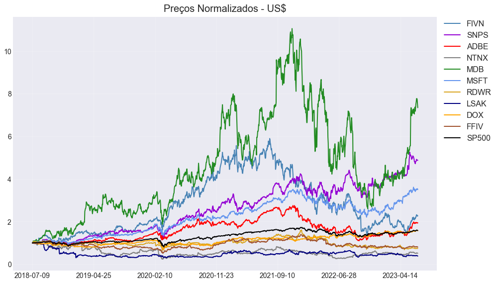

```python
print("\n9. Exibindo o gráfico referente à evolução do preço das ações:\n")

# Exibe uma plotagem referente aos preços normalizados das ações
show_plot(norm_df, 'Preços Normalizados - US$')
```

```
10. Exibindo o gráfico referente à distribuição do preço das ações:
```

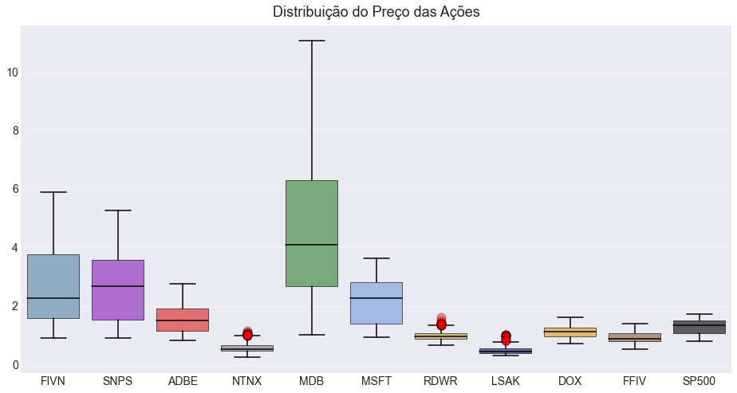

```python
print("\n10. Exibindo o gráfico referente à distribuição do preço das ações:\n")

# Exibe o gráfico de caixa com a variação do preço das ações
box_plot(norm_df, 'Distribuição do Preço das Ações')
```

## 4.2 Retorno Diário das Ações

Durante a análise do desempenho das ações, o cálculo do retorno diário representa uma métrica de grande interesse. Essa medida é utilizada para indicar a variação percentual do valor de uma ação ao longo de um único dia, fornecendo informações relevantes para a escolha das empresas nas quais desejamos investir. A seguir, apresentamos a definição da função responsável por calcular o retorno diário de uma ação, seguida pela sua aplicação na investigação do conjunto de dados utilizado neste trabalho. Essa abordagem nos permite explorar e compreender a volatilidade e as flutuações diárias das ações, auxiliando na análise e tomada de decisões informadas.

```python
# Define a função para calcular o retorno diário de uma ação
def daily_return(df):
    # Gera uma cópia do conjunto original
    df_daily_return = df.copy()
    # Percorre as colunas
    for i in df.columns[1:]:
        # Percorre as linhas
        for j in range(1, len(df)):
            # Calcula a variação do preço de fechamento do dia anterior
            df_daily_return[i][j] = ((df[i][j] - df[i][j-1]) / df[i][j-1]) * 100
        # Defina o valor da primeira linha como zero
        df_daily_return[i][0] = 0
    # Retorna o resultado obtido
    return df_daily_return
```

```python
print("\n11. Exibindo os dados referentes ao retorno diário do preço das ações:\n")

# Obtém os retornos diários para o nosso conjunto de dados
stocks_daily_return = daily_return(df)

# Exibe o resultado obtido
stocks_daily_return
```

```
11. Exibindo os dados referentes ao retorno diário do preço das ações:
```

|  | Date | FIVN | SNPS | ADBE | NTNX | MDB | MSFT | RDWR | LSAK | DOX | FFIV | SP500 |
| --- | --- | --- | --- | --- | --- | --- | --- | --- | --- | --- | --- | --- |
| 0 | 2018-07-09 | 0.00 | 0.00 | 0.00 | 0.00 | 0.00 | 0.00 | 0.00 | 0.00 | 0.00 | 0.00 | 0.00 |
| 1 | 2018-07-10 | -1.38 | 0.57 | -0.46 | 0.96 | -0.23 | 0.27 | 0.77 | 0.11 | -0.15 | 0.40 | 0.35 |
| 2 | 2018-07-11 | -0.71 | 0.22 | -0.21 | 2.89 | 0.85 | -0.14 | 1.80 | -0.43 | -0.06 | -2.07 | -0.71 |
| 3 | 2018-07-12 | 1.18 | 2.57 | 2.72 | 3.84 | 8.72 | 2.17 | 2.36 | -0.64 | 1.43 | 1.38 | 0.87 |
| 4 | 2018-07-13 | -0.37 | -0.08 | 1.46 | -1.69 | -1.62 | 1.19 | 1.14 | 1.29 | 0.09 | -0.74 | 0.11 |
| ... | ... | ... | ... | ... | ... | ... | ... | ... | ... | ... | ... | ... |
| 1253 | 2023-06-30 | 2.63 | 1.76 | 1.08 | 3.58 | 1.99 | 1.64 | -1.07 | 1.60 | 0.86 | 0.34 | 1.23 |
| 1254 | 2023-07-03 | -0.62 | -0.32 | -0.77 | 0.64 | 0.10 | -0.75 | 0.26 | 0.79 | -0.17 | -0.10 | 0.12 |
| 1255 | 2023-07-05 | -0.46 | -0.29 | 0.42 | -1.06 | -0.45 | 0.05 | -1.39 | -3.91 | -0.69 | 0.08 | -0.20 |
| 1256 | 2023-07-06 | -1.79 | -0.38 | -1.23 | -2.36 | -2.58 | 0.92 | -0.31 | -1.08 | -0.81 | -2.10 | -0.79 |
| 1257 | 2023-07-07 | 0.97 | 0.04 | 0.83 | 0.11 | -2.61 | -1.19 | 1.78 | -1.92 | -0.20 | 0.17 | -0.29 |

1258 rows × 12 columns

```
12. Exibindo o gráfico referente à variação do preço do retorno diário das ações:
```

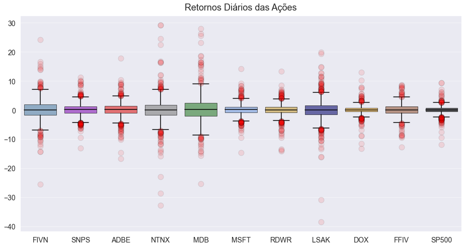

```python
print("\n12. Exibindo o gráfico referente à variação do preço do retorno diário \
das ações:\n")

# Exibe o gráfico de caixa com a variação dos retornos diários de cada ação
box_plot(stocks_daily_return, 'Retornos Diários das Ações')
```

Ao observar a figura acima, podemos notar que os retornos das ações apresentam uma distribuição normalizada com média zero. Além disso, em relação ao indicador S&P 500, a amplitude dos retornos diários ficou dentro de uma faixa de variação de aproximadamente ±10%. Dentre as empresas analisadas, aquelas que apresentaram os maiores *outliers* nos retornos diários foram *Nutanix*, *MongoDB*, *Five9* e *Lesaka Technologies*. Curiosamente, a empresa *Lesaka Technologies* registrou o menor retorno diário em relação às demais empresas. Para obter uma visão mais detalhada dos retornos diários das ações, abaixo está o resumo estatístico que inclui os valores mínimo e máximo, os quais correspondem aos *outliers* destacados na figura anteriormente apresentada.

```python
print("\n13. Exibindo o resumo estatístico dos dados referentes aos retornos \
diários das ações:\n")

# Exibe um resumo estatístico dos dados relacionados aos retornos diários das ações
stocks_daily_return.describe()
```

```
13. Exibindo o resumo estatístico dos dados referentes aos retornos diários das ações:
```

|  | FIVN | SNPS | ADBE | NTNX | MDB | MSFT | RDWR | LSAK | DOX | FFIV | SP500 |
| --- | --- | --- | --- | --- | --- | --- | --- | --- | --- | --- | --- |
| count | 1258.00 | 1258.00 | 1258.00 | 1258.00 | 1258.00 | 1258.00 | 1.26e+03 | 1258.00 | 1258.00 | 1.26e+03 | 1258.00 |
| mean | 0.12 | 0.15 | 0.08 | 0.02 | 0.25 | 0.12 | -2.83e-03 | -0.01 | 0.05 | 3.31e-03 | 0.05 |
| std | 3.35 | 2.19 | 2.40 | 3.86 | 4.38 | 1.97 | 2.00e+00 | 3.51 | 1.49 | 2.02e+00 | 1.37 |
| min | -25.56 | -13.19 | -16.79 | -32.72 | -25.32 | -14.74 | -1.42e+01 | -38.44 | -13.25 | -1.28e+01 | -11.98 |
| 25% | -1.66 | -0.95 | -1.06 | -1.69 | -2.00 | -0.84 | -8.84e-01 | -1.59 | -0.57 | -1.03e+00 | -0.53 |
| 50% | 0.09 | 0.17 | 0.17 | 0.01 | 0.23 | 0.11 | 2.88e-02 | 0.00 | 0.05 | 3.13e-02 | 0.08 |
| 75% | 1.90 | 1.27 | 1.31 | 1.81 | 2.43 | 1.11 | 1.01e+00 | 1.51 | 0.73 | 1.17e+00 | 0.71 |
| max | 24.17 | 11.20 | 17.72 | 29.17 | 28.01 | 14.22 | 1.32e+01 | 19.81 | 12.96 | 8.59e+00 | 9.38 |

A figura a seguir apresenta o gráfico de distribuição dos retornos diários para cada ação, permitindo uma visualização clara da distribuição dos valores em torno da média zero. Esse gráfico fornece uma compreensão sobre a variabilidade dos retornos diários e possibilita a identificação de padrões, assim como a presença de valores atípicos.

```
14. Exibindo o gráfico referente à distribuição dos retornos diários das ações:
```

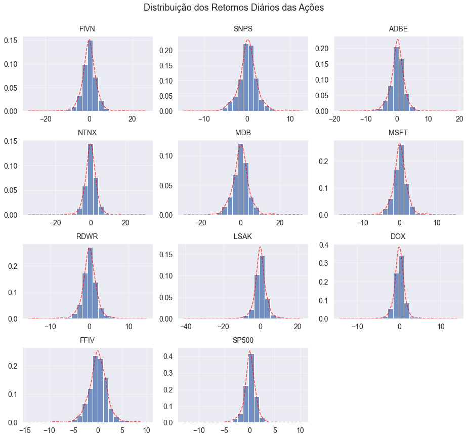

```python
print("\n14. Exibindo o gráfico referente à distribuição dos retornos diários \
das ações:\n")

# Exibe a distribuição relacionada aos retornos diários das ações
dist_plot(stocks_daily_return, 'Distribuição dos Retornos Diários das Ações')
```

Para visualizar a relação entre os retornos diários de duas ações, utilizamos uma matriz de correlação. Esse instrumento é essencial para analisar as conexões e os movimentos conjuntos das ações, o que auxilia na composição e no gerenciamento de carteiras de investimento, conforme afirma Rocha (2022) [26]. A correlação é a medida dessa relação entre as variáveis e pode ser classificada da seguinte maneira:

- Correlação positiva: ocorre quando há uma tendência crescente nos pontos, ou seja, conforme uma variável independente aumenta, a dependente também aumenta;
- Correlação negativa: ocorre quando há uma tendência decrescente nos pontos, ou seja, conforme uma variável independente aumenta, a dependente diminui;
- Correlação nula: ocorre quando os pontos não seguem uma tendência clara, ou seja, existe uma dispersão entre eles. Isso indica a ausência de uma correlação aparente entre as variáveis.

A matriz de correlação exibe os valores de correlação de Pearson, que medem o grau de relação linear entre cada par de variáveis. Esses valores variam entre -1 e +1. Se as duas variáveis tendem a aumentar e diminuir juntas, o valor de correlação é positivo. Se uma variável aumenta enquanto a outra diminui, o valor de correlação é negativo.

A seguir, apresentamos a definição do código responsável por exibir a matriz de correlação de um conjunto de dados. Posteriormente, exibimos a matriz de correlação para os retornos diários das ações analisadas, permitindo uma compreensão mais aprofundada da relação entre elas.

```python
# Define a função para calcular e plotar a matriz de correlação
def correlation_matrix(df, title):
    # Calcula a matriz de correlação
    correlations = df.corr()
    # Define o mapa de cor que será utilizado
    cmap = sns.diverging_palette(250, 10, as_cmap=True)
    # Configura o tamanho do gráfico
    plt.figure(figsize=(14, 8))
    # Plotagem
    sns.heatmap(correlations, cmap=cmap,
                xticklabels=correlations.columns,
                yticklabels=correlations.columns,
                cbar=True,
                annot=True, annot_kws={'size': 13})
    # Configura título e eixos do gráfico
    plt.suptitle(title, x=0.45, y=0.95, fontsize=18)
    plt.xticks(fontsize=12)
    plt.yticks(fontsize=12)
    # Exibe o gráfico
    plt.tight_layout()
    plt.show()
```

```
15. Exibindo a matriz de corelação referente aos retornos diários das ações:
```

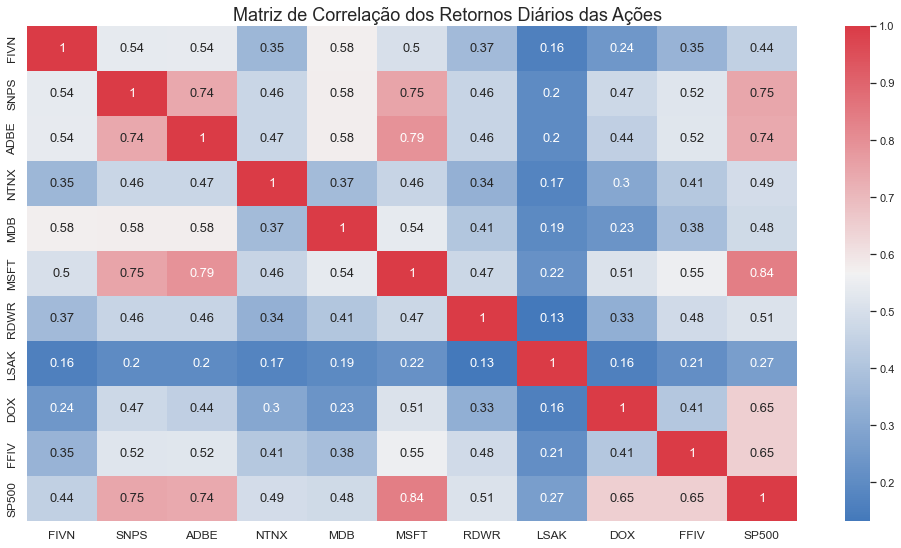

```python
print("\n15. Exibindo a matriz de corelação referente aos retornos diários das \
ações:\n")

# Exibe a matriz de correlação para os retornos diários das ações
correlation_matrix(stocks_daily_return,
                   'Matriz de Correlação dos Retornos Diários das Ações')
```

Ao analisar os valores retornados, verificamos que todas as variáveis apresentam correlações positivas. Isso indica que os retornos diários das ações tendem a caminhar juntos, ou seja, se uma ação apresenta um aumento em seu retorno diário, a outra também tende a ter um aumento. Da mesma forma, se o retorno diário de uma ação diminui, isso também ocorre com os valores relacionados à outra ação.

Para visualizar essa tendência, utilizamos um diagrama de dispersão. Essa ferramenta gráfica permite observar a correlação entre dois conjuntos de dados. A proximidade dos pontos no diagrama auxilia na identificação da relação entre causa e efeito. Essa dispersão pode ser classificada da seguinte maneira:

- Dispersão fraca: quanto menor a correlação entre as variáveis, mais dispersos estarão os pontos no diagrama;
- Dispersão forte: quanto maior a correlação entre as variáveis, maior será a proximidade dos pontos no diagrama.

A seguir, apresentamos o diagrama de dispersão que relaciona os retornos diários do índice S&P 500 e das ações de algumas empresas. Ao analisar esses gráficos, podemos observar que os retornos diários das ações estão de fato relacionados aos retornos do índice S&P 500, indicando uma influência mútua entre eles.

```
16. Exibindo o diagrama de dispersão para os retornos diários do índice S&P 500 e as ações da Microsoft:
```

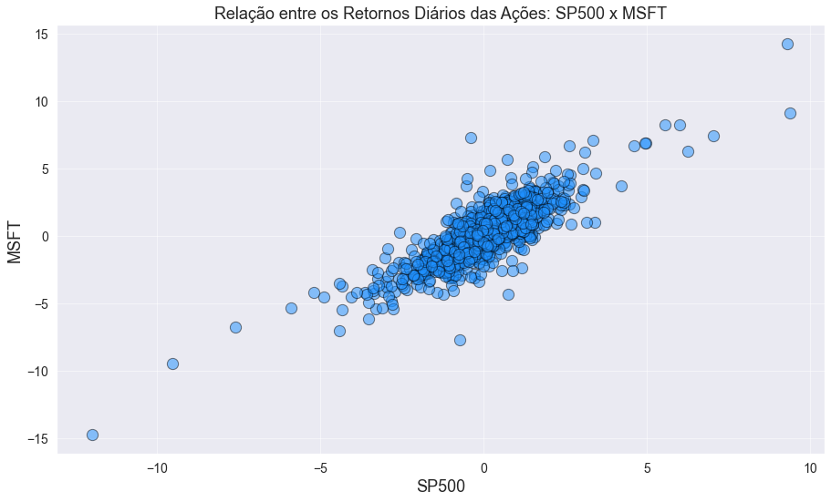

```python
print("\n16. Exibindo o diagrama de dispersão para os retornos diários do \
índice S&P 500 e as ações da Microsoft:\n")

# Exibe o diagrama de dispersão para os retornos diários do índice S&P 500 e as
# ações da Microsoft
scatter_plot(stocks_daily_return, 'SP500', 'MSFT', 'dodgerblue')
```

```
17. Exibindo o diagrama de dispersão para os retornos diários do índice S&P 500 e as ações da Adobe, MongoDB, Radware e Lesaka Technologies:
```

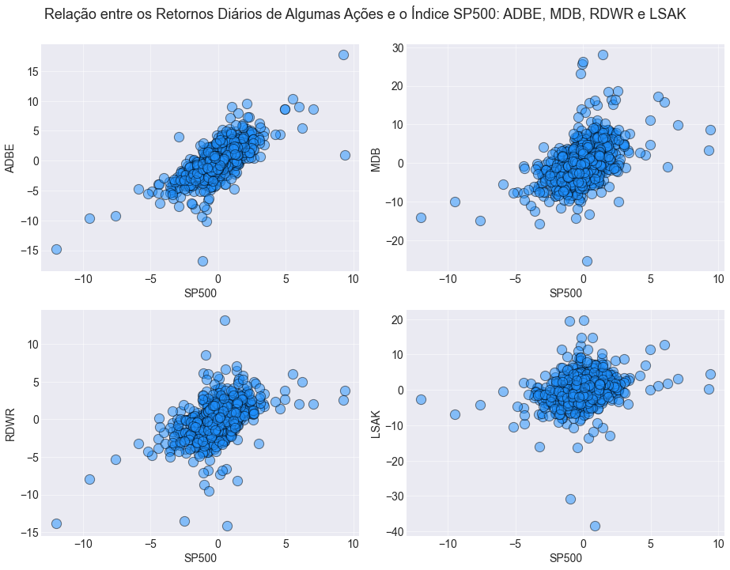

```python
print("\n17. Exibindo o diagrama de dispersão para os retornos diários do \
índice S&P 500 e as ações da Adobe, MongoDB, Radware e Lesaka Technologies:\n")

# Configura o tamanho do gráfico
plt.figure(figsize=(13, 10))

# Percorre a lista com o nome das ações
for i,stock in enumerate(['ADBE', 'MDB', 'RDWR',  'LSAK']):
    # Define o local do subplot
    ax = plt.subplot(2, 2, i+1)
    # Plota o gráfico de dispersão entre a ação e o índice S&P 500
    sns.scatterplot(data=stocks_daily_return, x='SP500', y=stock, color='dodgerblue',
                    alpha=0.5, linewidth=1, edgecolor='black', s=150,
                    legend=False)
    # Configura título e eixos do subplot
    #plt.title(f"SP500 x {stock}", y=1.02, fontsize=14)
    ax.set_xlabel('SP500', fontsize=14)
    ax.set_ylabel(stock, fontsize=14)
    ax.tick_params(axis='x', labelsize=14)
    ax.tick_params(axis='y', labelsize=14)

# Configura o título principal do gráfico
plt.suptitle("Relação entre os Retornos Diários de Algumas Ações e o Índice SP500: ADBE, MDB, RDWR e LSAK", y=1, fontsize=18)

# Exibe o gráfico
plt.tight_layout()
plt.show()
```

## 4.3 Cálculo dos Índices Alfa e Beta

Após a preparação dos dados, que envolveu a normalização dos valores e o cálculo dos retornos diários das ações, aplicamos o modelo CAPM para precificar nossos ativos financeiros e analisar a relação entre o risco e o rendimento de cada um deles dentro de nossa carteira de investimento.

Inicialmente, estimamos o valor do índice *Beta* e do indicador *Alfa* para cada uma das ações selecionadas. Esses dois indicadores financeiros são utilizados para avaliar o desempenho de um fundo de investimento e auxiliar os investidores na tomada de decisão sobre a compra e venda de ativos em suas carteiras de investimento. O índice *Beta* mede o risco sistemático de um ativo em comparação com o comportamento do mercado, enquanto o indicador *Alfa* descreve a capacidade de um investimento gerar lucros acima do esperado no mercado. Por exemplo, um valor de *Alfa = 0,2* para uma ação indica que o retorno da carteira superou o índice de referência S&P 500 em 20%.

É importante destacar que o mercado como um todo possui um valor de *Beta* igual a 1. Ações com valores acima de 1 são consideradas mais voláteis em relação ao mercado. O *Beta* representa o coeficiente de regressão (inclinação) ao relacionar o desempenho do mercado com o desempenho da ação. Portanto, antes de aplicar o modelo CAPM, é necessário estimar o valor do coeficiente *Beta* para todas as ações selecionadas.

Para calcular os valores dos indicadores *Beta* e *Alfa*, utilizamos o trecho de código apresentado abaixo. Esse código realiza os cálculos utilizando o conjunto de dados dos retornos diários das ações, obtido anteriormente. Os valores calculados para esses indicadores são armazenados para uso posterior na estimativa de retorno de nossas ações por meio do modelo CAPM. Além disso, o código exibe um gráfico de dispersão com sua respectiva linha de regressão para cada uma das ações, considerando os valores dos retornos diários do índice S&P 500. Esse gráfico proporciona uma visualização das tendências e da relação entre os retornos das ações e o índice de referência.

```
18. Exibindo o diagrama de dispersão com sua respectiva linha de regressão para cada uma das ações, considerando os valores dos retornos diários do índice S&P 500:
```

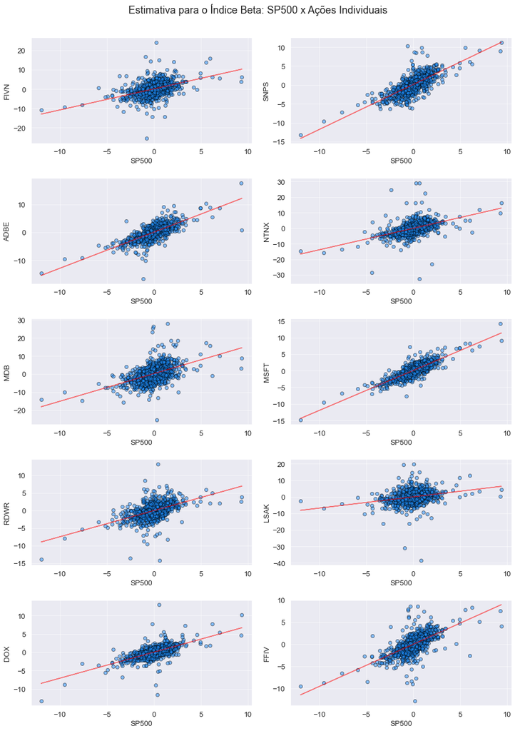

```python
print("\n18. Exibindo o diagrama de dispersão com sua respectiva linha de \
regressão para cada uma das ações, considerando os valores dos retornos diários \
do índice S&P 500:\n")

# Dicionários para armazenar os valores de Beta e alfa
beta = {}
alfa = {}

# Configura os subplots
fig, axes = plt.subplots(5, 2, figsize=(13,18))
axes = axes.flatten()

# Percorre os retornos diários de cada ação
for i, stock in enumerate(stocks_daily_return.columns):
    # Ignora as colunas que armazenam a data e o valor do índice S&P 500
    if stock != 'Date' and stock != 'SP500':
        # Plota o gráfico de dispersão entre a ação e o índice S&P 500
        sns.scatterplot(x='SP500', y=stock, data=stocks_daily_return,
                        color='dodgerblue', alpha=0.5, linewidth=1,
                        edgecolor='black', legend=False, ax=axes[i-1])
        # Calcula os coeficientes Beta e alfa
        # Ajusta uma linha de regressão, utilizando um polinômio de grau 1
        b, a = np.polyfit(stocks_daily_return['SP500'],
                          stocks_daily_return[stock], 1)
        # Plota a linha de regressão
        regression_line = b * stocks_daily_return['SP500'] + a
        axes[i-1].plot(stocks_daily_return['SP500'],
                       regression_line, color='red', linewidth=1.5, alpha=0.5)
        # Ajusta o tamanho da fonte dos eixos
        axes[i-1].xaxis.label.set_size(13)
        axes[i-1].yaxis.label.set_size(13)
        axes[i-1].xaxis.set_tick_params(labelsize=13)
        axes[i-1].yaxis.set_tick_params(labelsize=13)
        # Insere os coeficientes de regressão nos dicionários
        beta[stock] = b
        alfa[stock] = a

# # Configura o título principal do gráfico
plt.suptitle("Estimativa para o Índice Beta: SP500 x Ações Individuais",
             y=1, fontsize=18)

# Exibe o gráfico
plt.tight_layout()
plt.show()
```

Com o objetivo de visualizar de forma mais clara os valores de *Alfa* e *Beta*, criamos um novo conjunto de dados que inclui esses indicadores. Além disso, acrescentamos os percentuais correspondentes ao índice *Alfa* e à volatilidade do índice *Beta* em relação ao mercado. Dessa maneira, podemos ter uma visão abrangente do desempenho de cada ação em relação ao mercado.

Essas informações adicionais são valiosas para avaliar a performance e a relação de risco-recompensa de cada ativo dentro da nossa carteira de investimento.

```python
# Cria um DataFrame com o nome de cada ação e os valores de Alfa e Beta
indices_CAPM = pd.DataFrame([alfa, beta]).transpose()
indices_CAPM.reset_index(inplace=True)
indices_CAPM.rename(columns = {'index': 'Ação', 0:'Alfa', 1:'Beta'}, inplace=True)

# Adiciona a coluna com o indicativo do percentual relacionado ao valor de Alfa
# Adiciona a coluna com o indicativo da volatilidade da ação em relação ao mercado
indices_CAPM['Alfa %'] = indices_CAPM['Alfa'] * 100
indices_CAPM['Volatilidade %'] = (indices_CAPM['Beta'] - 1) * 100
indices_CAPM = indices_CAPM[['Ação', 'Alfa', 'Alfa %', 'Beta', 'Volatilidade %']]

print("\n19. Exibindo os valores de Alfa e Beta, obtidos para as ações que \
foram selecionadas:\n")

# Exibe o resultado, formatando a quantidade de casas decimais
indices_CAPM.style.format({'Alfa': '{:.10f}', 'Alfa %': '{:.2f}',
                           'Beta': '{:.10f}', 'Volatilidade %': '{:.2f}'})
```

```
19. Exibindo os valores de Alfa e Beta, obtidos para as ações que foram selecionadas:
```

|  | Ação | Alfa | Alfa % | Beta | Volatilidade % |
| --- | --- | --- | --- | --- | --- |
| 0 | FIVN | 0.0719189699 | 7.19 | 1.0882538994 | 8.83 |
| 1 | SNPS | 0.0953120366 | 9.53 | 1.1910291126 | 19.10 |
| 2 | ADBE | 0.0224667595 | 2.25 | 1.2950272893 | 29.50 |
| 3 | NTNX | -0.0409890012 | -4.10 | 1.3857142116 | 38.57 |
| 4 | MDB | 0.1829963817 | 18.30 | 1.5320611738 | 53.21 |
| 5 | MSFT | 0.0638484541 | 6.38 | 1.2038093029 | 20.38 |
| 6 | RDWR | -0.0369208118 | -3.69 | 0.7447998005 | -25.52 |
| 7 | LSAK | -0.0430856785 | -4.31 | 0.6809696170 | -31.90 |
| 8 | DOX | 0.0145989197 | 1.46 | 0.7099355182 | -29.01 |
| 9 | FFIV | -0.0404121256 | -4.04 | 0.9551642951 | -4.48 |

## 4.4 CAPM - Capital Asset Pricing Model

Agora que nossos dados foram preparados, com a normalização e o cálculo dos retornos diários das ações, podemos avançar para a aplicação do modelo CAPM a fim de estimar os retornos esperados ajustados ao risco. O modelo CAPM é representado pela seguinte fórmula:

$$E(R_i) = R_f + \beta_i \times (E(R_m) - R_f)$$

Inicialmente, calculamos a estimativa para o retorno esperado do mercado *E(R<sub>m</sub>)*, com base nos dados históricos analisados durante o período de 5 anos. Multiplicamos a média dos retornos diários do S&P 500 por 252, considerando que há 252 dias de negociação em um ano [26]. Dessa forma, obtemos o retorno anualizado do mercado. Esse cálculo é essencial para a aplicação do modelo CAPM, pois fornece uma referência para o retorno esperado pelo investidor, considerando o risco inerente ao mercado.

O próximo passo é utilizar o coeficiente *Beta* (*B<sub>i</sub>*) de cada ação, que mede sua sensibilidade em relação às variações do mercado, e combiná-lo com o retorno esperado do mercado e a taxa livre de risco (*R<sub>f</sub>*) para estimar o retorno esperado ajustado ao risco para cada ação. Essa estimativa de retorno é fundamental para a tomada de decisão de investimento, pois permite avaliar se o retorno esperado de uma ação está de acordo com seu risco relativo. Portanto, o modelo CAPM desempenha um papel importante na precificação de ativos financeiros e na composição de uma carteira de investimentos eficiente.

```python
# Calcula o retorno esperado do mercado
rm = stocks_daily_return['SP500'].mean() * 252

# Exibe o resultado
print(f"\n20. Retorno esperado do mercado (S&P 500): {rm:.2f}%\n")
```

```
20. Retorno esperado do mercado (S&P 500): 11.54%
```

Considerando a taxa de retorno livre de risco igual a zero, aplicamos o modelo CAPM para estimar o retorno esperado das ações que planejamos incluir em nossa carteira de investimentos. O modelo CAPM nos permite avaliar o retorno esperado de um ativo ao levar em consideração seu risco sistemático, representado pelo coeficiente *Beta*. Com base nessa análise, podemos tomar decisões sobre a seleção e a alocação de ativos em nossa carteira, considerando o equilíbrio entre risco e retorno.

```python
# Define o dicionário para armazenar o retorno esperado para as ações
ER = {}

# Define o retorno livre de risco
rf = 0

# Obtém uma lista com o nome das ações
keys = list(beta.keys())

# Aplica a equação do CAPM
for i in keys:
    ER[i] = rf + (beta[i] * (rm - rf))

# Exibe o resultado
print("\n21. Retorno esperado para cada ação, utilizando o modelo CAPM:\n")

for i in keys:
    print(f"\u2022 Retorno esperado para {i}: {ER[i]:.2f}%")
```

```
21. Retorno esperado para cada ação, utilizando o modelo CAPM:

• Retorno esperado para FIVN: 12.55%
• Retorno esperado para SNPS: 13.74%
• Retorno esperado para ADBE: 14.94%
• Retorno esperado para NTNX: 15.99%
• Retorno esperado para MDB: 17.67%
• Retorno esperado para MSFT: 13.89%
• Retorno esperado para RDWR: 8.59%
• Retorno esperado para LSAK: 7.86%
• Retorno esperado para DOX: 8.19%
• Retorno esperado para FFIV: 11.02%
```

Ao analisarmos os resultados, podemos obter uma visão clara do retorno que um investidor deve esperar para ser devidamente compensado pelo risco adicional, caso opte por investir em alguma das ações selecionadas. Por exemplo, se o investidor estiver considerando investir nas ações da *MongoDB*, é necessário ter uma expectativa de retorno de aproximadamente 17,67% para justificar os riscos adicionais envolvidos. Essa estimativa de retorno é obtida com base nos dados históricos para o período analisado. Para calcular o retorno real com base nesses dados, podemos utilizar o trecho de código a seguir. Essa análise ajuda os investidores a avaliar e comparar as oportunidades de investimento e a tomar decisões embasadas e informadas sobre sua carteira de investimentos.

```python
# Exibe o resultado
print("\n22. Retorno real para cada ação, baseado nos dados históricos:\n")

for i in keys:
    print(f"\u2022 Retorno real para {i}: {stocks_daily_return[i].mean() * 252:.2f}%")
```

```
22. Retorno real para cada ação, baseado nos dados históricos:

• Retorno real para FIVN: 30.68%
• Retorno real para SNPS: 37.76%
• Retorno real para ADBE: 20.60%
• Retorno real para NTNX: 5.66%
• Retorno real para MDB: 63.79%
• Retorno real para MSFT: 29.98%
• Retorno real para RDWR: -0.71%
• Retorno real para LSAK: -3.00%
• Retorno real para DOX: 11.87%
• Retorno real para FFIV: 0.83%
```

Para uma melhor visualização e comparação dos retornos obtidos, podemos utilizar um gráfico de barras. Esse tipo de gráfico nos permite visualizar de forma clara e intuitiva os valores dos retornos para cada uma das ações analisadas. Ao plotar o gráfico de barras, podemos observar as diferenças nos retornos entre as ações selecionadas. Essa representação gráfica nos ajuda a identificar visualmente quais ações apresentam os maiores e os menores retornos em relação ao investimento. Com base nessa análise, os investidores podem tomar decisões embasadas sobre a alocação de seus recursos e selecionar as ações que melhor se adequam aos seus objetivos financeiros.

```
23. Exibindo o gráfico de barras com o comparativo entre o retorno esperado e o retorno real, para as ações selecionadas:
```

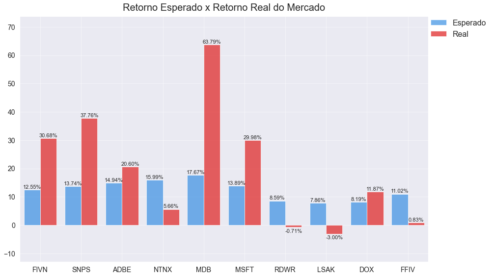

```python
print("\n23. Exibindo o gráfico de barras com o comparativo entre o retorno \
esperado e o retorno real, para as ações selecionadas:\n")

# Obtém os dados: nome da ação, retorno esperado e retorno real
stocks = [key for key in ER.keys()]
esperado = [value for value in ER.values()]
real = [(stocks_daily_return[key].mean() * 252) for key in ER.keys()]

# Armazena os dados em um dicionário
dados = {'Ação': stocks,
         'Esperado': esperado,
         'Real': real}

# Cria um DataFrame para armazenar os valores
dados_df = pd.DataFrame(dados)

# Configura o tamanho e estilo do gráfico
plt.figure(figsize=(14, 8))
sns.set(style='darkgrid')

# Plotagem das barras
ax = sns.barplot(x='Ação', y='value', hue='variable',
                 data=pd.melt(dados_df, 'Ação'), palette=['dodgerblue', 'red'],
                 alpha=0.7)

# Adiciona o percentual sobre cada barra
for p in ax.patches:
    # Verifica a posição vertical do texto
    if p.get_height() >= 0:
        offset = 5.25
    else:
        offset = -8.25
    # Insere o texto com o percentual
    ax.annotate(f'{p.get_height():.2f}%',
                (p.get_x() + p.get_width() / 2., p.get_height()),
                ha='center', va='center', xytext=(0, offset),
                textcoords='offset points', fontsize=11)

# Configura título e eixos do gráfico
plt.title('Retorno Esperado x Retorno Real do Mercado', y=1.01, fontsize=20)
plt.xlabel(None)
plt.ylabel(None)
plt.xticks(fontsize=14)
plt.yticks(fontsize=14)

# Obtém os limites do eixo Y
min_y = min(esperado) if min(esperado) < min(real) else min(real)
max_y = max(esperado) if max(esperado) > max(real) else max(real)

# Ajusta o limite do eixo Y
plt.ylim(min_y - 10, max_y + 10)

# Legenda do gráfico
plt.legend(fontsize=16, bbox_to_anchor=(1.15, 1), borderaxespad=0)

# Exibe o gráfico
plt.grid(True)
plt.tight_layout()
plt.show()
```

Ao analisarmos os resultados, observamos que o retorno real de mercado para as ações da *MongoDB* foi de aproximadamente 63,79%. Esse valor representa o retorno efetivamente obtido pelos investidores que apostaram nessa ação. Em contraste, a aplicação do modelo CAPM considerou um retorno esperado de aproximadamente 17,67% para as ações da *MongoDB*. Podemos concluir, portanto, que o retorno real superou significativamente as expectativas calculadas pelo modelo CAPM. Essa diferença pode ser atribuída a diversos fatores, como a dinâmica do mercado, eventos específicos relacionados à empresa ou até mesmo ação de investidores influentes.

Por outro lado, para as ações da *Lesaka Technologies*, o retorno esperado estimado pelo modelo CAPM foi de aproximadamente 7,86%. No entanto, o retorno real para essas ações foi negativo, o que significa que os investidores que apostaram na *Lesaka Technologies* sofreram prejuízo ao invés de obter ganhos.

Essas diferenças entre os retornos esperados e os retornos reais ressaltam a importância de uma análise aprofundada e da consideração de outros fatores além do modelo CAPM na tomada de decisões de investimento. É fundamental acompanhar de perto o desempenho das empresas, as tendências do mercado e os eventos relevantes que podem impactar os retornos.

Podemos visualizar essa situação por meio do gráfico de preços das ações, que foi apresentado durante a análise exploratória dos dados e reproduzido novamente para fins de praticidade. Esse gráfico nos permite visualizar a trajetória dos preços das ações ao longo do tempo e identificar claramente a diferença de desempenho entre as ações da *MongoDB* e da *Lesaka Technologies*. É evidente que os investidores que optaram por investir nas ações da *MongoDB* obtiveram ganhos significativos, enquanto aqueles que investiram nas ações da *Lesaka Technologies* enfrentaram perdas.

Esses exemplos destacam a importância de uma análise criteriosa e do monitoramento constante do desempenho das ações, a fim de tomar decisões informadas e maximizar os resultados dos investimentos.

```
24. Exibindo o gráfico referente à evolução do preço das ações:
```

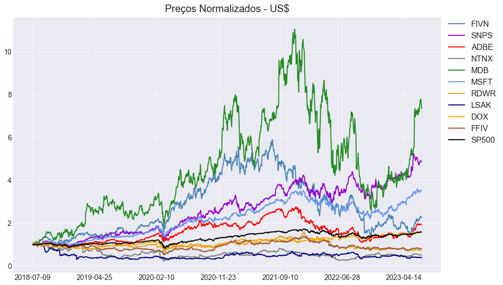

```python
print("\n24. Exibindo o gráfico referente à evolução do preço das ações:\n")

# Exibe uma plotagem referente aos preços normalizados das ações
show_plot(norm_df, 'Preços Normalizados - US$')
```

```python
print("\n25. Exibindo os dados referentes ao comparativo entre o retorno \
esperado e o retorno real, para as ações selecionadas:\n")

# Exibe o comparativo entre os retornos, utilizando um formato de tabela
dados_df.style.format({'Esperado': '{:.2f}%', 'Real': '{:.2f}%'})
```

```
25. Exibindo os dados referentes ao comparativo entre o retorno esperado e o retorno real, para as ações selecionadas:
```

|  | Ação | Esperado | Real |
| --- | --- | --- | --- |
| 0 | FIVN | 12.55% | 30.68% |
| 1 | SNPS | 13.74% | 37.76% |
| 2 | ADBE | 14.94% | 20.60% |
| 3 | NTNX | 15.99% | 5.66% |
| 4 | MDB | 17.67% | 63.79% |
| 5 | MSFT | 13.89% | 29.98% |
| 6 | RDWR | 8.59% | -0.71% |
| 7 | LSAK | 7.86% | -3.00% |
| 8 | DOX | 8.19% | 11.87% |
| 9 | FFIV | 11.02% | 0.83% |

Ao considerarmos a hipótese de incluir essas ações em nossa carteira de investimentos, podemos assumir que iremos atribuir pesos iguais a cada uma delas. Essa abordagem nos permite calcular o retorno esperado de nosso portfólio, levando em consideração o modelo CAPM. A atribuição de pesos iguais às ações significa que cada ação terá a mesma importância na composição de nosso portfólio. Dessa forma, o desempenho de cada ação terá um impacto equivalente no retorno total de nosso portfólio.

Utilizando o modelo CAPM, podemos estimar o retorno esperado de nosso portfólio, considerando o risco sistemático representado pelo índice *Beta* de cada ação e o retorno esperado do mercado. Essa estimativa nos fornece uma referência para avaliar o desempenho potencial de nosso portfólio com base nas características de risco e retorno de cada uma das ações incluídas.

É importante ressaltar que a atribuição de pesos iguais a todas as ações pressupõe que todas elas têm o mesmo grau de atratividade e risco. Essa simplificação nos permite obter uma estimativa geral do retorno esperado de nosso portfólio, mas é fundamental realizar uma análise mais aprofundada e considerar outros fatores relevantes na construção de uma carteira de investimentos diversificada e equilibrada.

```python
print("\n26. Calculando o retorno esperado e o retorno real para a carteira de \
investimentos, com base no modelo CAPM:\n")

# Assume a atribuição de pesos iguais para todas as ações
portfolio_weights = 1/10 * np.ones(10)

print(f"\u2022 Pesos atribuídos para as ações de nossa carteira:\
{list(portfolio_weights)}\n")

# Calcula o retorno esperado do portfólio
ER_portfolio = sum(list(dados_df['Esperado']) * portfolio_weights)

# Calcula o retorno real do mercado
R_real = sum(list(dados_df['Real']) * portfolio_weights)

print(f"\u2022 Retorno esperado (modelo CAPM): {ER_portfolio:.2f}%\n")
print(f"\u2022 Retorno real do mercado: {R_real:.2f}%\n")
```

```
26. Calculando o retorno esperado e o retorno real para a carteira de investimentos, com base no modelo CAPM:

• Pesos atribuídos para as ações de nossa carteira:[0.1, 0.1, 0.1, 0.1, 0.1, 0.1, 0.1, 0.1, 0.1, 0.1]

• Retorno esperado (modelo CAPM): 12.44%

• Retorno real do mercado: 19.74%
```

Na simulação realizada neste trabalho, ao aplicarmos o modelo CAPM, obtemos um valor de retorno de 12,44%. Esse resultado representa a estimativa do retorno esperado para nosso portfólio, levando em consideração o risco associado aos ativos selecionados.

# 5. Discussão e Limitações da Pesquisa

Quando alguém decide por investir em um ativo é comum ter em mente a expectativa de retorno desse investimento. Para essa tarefa, existem diversos modelos disponíveis. Um dos mais reconhecidos é o modelo CAPM (*Capital Asset Pricing Model*), cujo objetivo é determinar a taxa de retorno teórica de um ativo financeiro. O modelo CAPM leva em consideração os riscos do investimento, assim como sua taxa livre de risco. No cálculo realizado pela aplicação de sua fórmula, o coeficiente *Beta* indica o risco associado ao investimento, também denominado de risco sistêmico de mercado.

Ao utilizar o CAPM, podemos identificar ativos que oferecem um equilíbrio favorável entre retorno e risco. De maneira ideal, um ativo com um retorno elevado e um risco reduzido seria considerado um candidato adequado para inclusão em um portfólio de investimentos bem equilibrado. Essa combinação de retorno atrativo e risco controlado é o que os investidores geralmente procuram ao construir uma carteira de investimentos diversificada. No modelo CAPM, o risco de um ativo é medido pelo seu *Beta*, que reflete a sensibilidade desse ativo às variações do mercado. Quanto maior o valor de *Beta*, maior o risco associado ao ativo. Ao estimar o retorno esperado de um ativo com base em seu *Beta* e no prêmio de risco do mercado, podemos fazer uma avaliação mais precisa de sua atratividade como componente de um portfólio.

Empresas onde o valor de *Beta* é menor que 1 oferecem um risco menor ao investidor, pois são consideradas empresas mais conservadoras. Logo, caso o investidor faça a escolha por investir em seus ativos, provavelmente terá um retorno abaixo da média, embora esteja correndo menos riscos. No estudo realizado neste trabalho, as empresas *Radware* (RDWR), *Lesaka Technologies* (LSAK), *Amdocs Limited* (DOX) e *F5* (FFIV) apresentaram um valor de *Beta* menor que 1. Observando o gráfico que apresenta o preço normalizado de suas ações, podemos perceber a desvalorização de todas elas em relação ao índice S&P 500, com exceção das ações da *Amdocs Limited*. A *Amdocs Limited* é uma empresa de origem israelense, que está no mercado há 40 anos trabalhando com sistemas de *software* para o mercado de telecomunicações.

Por outro lado, as empresas onde o valor de *Beta* é maior que 1 oferecem um risco maior ao investivor. Entretanto, apesar desse risco, caso o investidor faça a escolha por investir em seus ativos, provavelmente, terá um retorno maior. No estudo realizado neste trabalho, as empresas *Five9* (FIVN), *Synopsys* (SNPS), *Adobe* (ADBE), *Nutanix* (NTNX), *MongoDB* (MDB) e *Microsoft* (MSFT) apresentaram um valor de *Beta* maior que 1. Observando o gráfico que apresenta o preço normalizado de suas ações, podemos perceber a valorização de todas elas em relação ao índice S&P 500, com exceção das ações da *Nutanix*. Curiosamente, apesar de ter apresentado um valor de *Beta* maior que 1 (β = 1,38), a *Nutanix* tem realizado uma auditoria em suas finanças, depois de descobrir problemas no custeio de seus produtos, o que certamente causou uma grande preocupação em seus investidores [27].

Os ativos do setor de tecnologia são conhecidos por sua volatilidade [28]. A natureza inovadora e em constante evolução desse setor, aliada à sensibilidade do mercado a fatores como notícias, lançamentos de produtos e mudanças regulatórias, contribui para a volatilidade dos ativos tecnológicos. A demanda por tecnologia está sujeita a flutuações e incertezas, o que pode levar a grandes oscilações nos preços dos ativos. Além disso, a concorrência acirrada entre as empresas de tecnologia e a rápida obsolescência de produtos e serviços podem adicionar um elemento adicional de volatilidade aos ativos desse setor. Investidores interessados em ativos tecnológicos devem estar preparados para lidar com a volatilidade e adotar estratégias de gerenciamento de risco adequadas para proteger seus investimentos.

Considerando nossa carteira de investimentos, o modelo CAPM alcançou um retorno esperado de 12,44%, contra 19,74% do retorno real. Assim, para os ativos que foram selecionados, podemos interpretar que nosso portfólio tem um desempenho esperado acima do retorno livre de risco e em linha com a remuneração exigida pelo mercado pelos riscos assumidos. No entanto, é importante destacar que essa é uma estimativa teórica e que os resultados reais podem variar de acordo com o desempenho dos ativos e as condições do mercado.

Embora o CAPM seja um modelo amplamente utilizado na precificação de ativos, é importante considerar suas limitações. O modelo é baseado em suposições simplificadas e pode não refletir completamente a complexidade dos mercados financeiros. Ao utilizar o modelo CAPM, é fundamental considerar suas limitações e complementar a análise com outras abordagens e modelos que levem em conta as particularidades dos ativos e do ambiente de investimento. Conforme cita Kumar (2023) [29], dentre algumas limitações que podem afetar sua aplicabilidade e precisão em certos contextos, temos:

- O modelo se baseia em uma série de suposições simplificadas, que nem sempre refletem a realidade dos mercados financeiros. Essas simplificações podem ser muito restritivas e não capturar a complexidade do comportamento dos investidores e dos próprios ativos.
- O cálculo realizado por sua fórmula geralmente utiliza eventos passados, porém, é importante ressaltar que a rentabilidade passada não garante a rentabilidade futura. Portanto, os resultados obtidos por meio do modelo podem não corresponder ao retorno real que um investidor irá obter.
- O modelo pressupõe que os mercados financeiros sejam eficientes, ou seja, que os preços dos ativos reflitam todas as informações disponíveis. No entanto, em mercados menos eficientes ou em períodos de extrema volatilidade, os preços dos ativos podem não seguir as previsões do modelo. Isso pode resultar em diferenças significativas entre os retornos esperados calculados pelo CAPM e os retornos reais obtidos pelos investidores.
- O modelo considera apenas o risco sistêmico, ou seja, o risco associado ao mercado como um todo. No entanto, existem fatores não sistêmicos, como riscos específicos de setor ou empresa, que podem afetar o retorno de um ativo e não são capturados pelo modelo. Ignorar esses fatores pode levar a uma sub ou superestimação do retorno esperado de um ativo, levando a decisões de investimento incorretas.
- O modelo utiliza a taxa livre de risco como um dos parâmetros fundamentais para o cálculo do retorno esperado. No entanto, a taxa livre de risco pode variar ao longo do tempo e não refletir adequadamente as condições econômicas atuais. Além disso, o modelo assume que todos os investidores têm acesso à mesma taxa livre de risco, o que pode não ser verdadeiro em todos os casos.

Como sugestões para trabalhos futuros, é recomendável explorar outras abordagens na seleção dos ativos que compõem o portfólio, bem como considerar alocações de pesos diferentes para calcular o retorno esperado. Além disso, é vantajoso explorar abordagens distintas daquelas utilizadas pelo modelo CAPM para a precificação de ativos. Nesse sentido, com base nas observações de Caetano (2021) [30], seria interessante explorar a aplicação de novos recursos, como o uso da Inteligência Artificial, para aprimorar a precificação de ativos financeiros.

# Referências Bibliográficas

[1] GOMES, Victor. Introdução ao Python para Análise de Dados Financeiros. Trading com Dados, 2020. Disponível em: https://www.tradingcomdados.com.br/conteudo/e-books. Acesso em: 14 jul. 2023.

[2] SORANCO, Daniel et al. Precificação de ativos baseado no modelo Capital Asset Pricing Model (CAPM). Pensar Contábil, v. 15, n. 58, 2014.

[3] FORSTER, Gilmar. Modelo de Precificação de Ativos – CAPM. CAP Accounting and Management-B4, v. 3, n. 3, p. 72-78, 2010.

[4] TORO BLOG. Bolsa de Valores no Brasil: o que é e como funciona a B3? 2023. Disponível em: https://blog.toroinvestimentos.com.br/bolsa/bolsa-de-valores-b3. Acesso em: 14 jul. 2023.

[5] ASSAF NETO, Alexandre. Mercado financeiro. 5. ed. São Paulo: Atlas, 2003.

[6] REIS, Tiago. Portfólio de ações: dicas para montar uma boa carteira de ativos. 2022. Disponível em: https://www.suno.com.br/artigos/portfolio-de-acoes. Acesso em: 14 jul. 2023.

[7] REIS, Tiago. Carteira de Investimentos: 5 passos práticos para você montar a sua. 2023. Disponível em: https://www.suno.com.br/guias/carteira-de-investimentos. Acesso em: 14 jul. 2023.

[8] S&P GLOBAL. S&P Dow Jones Indices: Index Methodology. 2023. Disponível em: https://bit.ly/3DkV95r. Acesso em: 14 jul. 2023.

[9] PINTO, Leonardo. O que é S&P 500? Saiba a importância do índice mais famoso do mundo. Disponível em: https://bit.ly/3JLjsgv. Acesso em: 09 jul. 2023.

[10] GITMAN, Lawrence J. et al. Princípios de administração financeira. 2010.

[11] ROSS, Stephen A. et al. Administração financeira. AMGH Editora, 2015.

[12] MELLAGI FILHO, Armando; ISHIKAWA, Sérgio. Mercado financeiro e de capitais. 2.ed. São Paulo: Atlas, 2007.

[13] BRIGHAM, Eugene F.; EHRHARDT, Michael C. Administração financeira: teoria e prática. 10. ed. São Paulo: Pioneira Thomson Learning, 2006.

[14] YAHOO! FINANCE. 2023. Disponível em: https://finance.yahoo.com/. Acesso em: 09 jul. 2023.

[15] FARIAS, Tácito Augusto; MOURA, Fábio Rodrigues; FIGUEIREDO, Luiz Eduardo Nascimento. Capital Asset Pricing Model: um estudo de caso ao segmento da construção civil. Revista de Economia Mackenzie, v. 14, n. 2, 2017.

[16] ARAÚJO, Elisson Alberto Tavares; DO CARMO OLIVEIRA, Victor; SILVA, Wendel Alex Castro. CAPM em estudos brasileiros: uma análise da pesquisa. Revista de Contabilidade e Organizações, v. 6, n. 15, p. 95-122, 2012.

[17] GROPPELLI, Angelico A.; NIKBAKHT, Ehsan; CASTRO, André Olimpio Mosselman Du Chenoy. Administração financeira. Saraiva, 1998.

[18] MARTELANC, Roy; PASIN, Rodrigo; CAVALCANTE, Francisco. Avaliação de empresas: um guia para fusões e aquisições e gestão de valor. Pearson Prentice Hall, 2005.

[19] SCHERER, Davi. Índice Beta. 2020. Disponível em: https://bit.ly/3PSLoTO. Acesso em: 11 jul. 2023.

[20] BLOG ROCK CONTENT. Veja como a análise setorial pode ser o diferencial para o sucesso dos seus esforços de vendas. 2019. Disponível em: https://rockcontent.com/br/blog/analise-setorial/. Acesso em: 09 jul. 2023.

[21] SYNOPSYS. Disponível em: https://www.synopsys.com/. Acesso em: 10 jul. 2023.

[22] ADOBE. 2021 Annual Report (Form 10-K). 2022. Disponível em: https://bit.ly/44DlZla. Acesso em: 10 jul. 2023.

[23] MONGODB. Disponível em: https://www.mongodb.com/. Acesso em: 10 jul. 2023.

[24] VALOR INVESTE. Apple segue como marca mais valiosa do mundo. 2022. Disponível em: https://bit.ly/43kXMiu. Acesso em: 10 jul. 2023.

[25] ROCHA, Giovana. Matriz de Correlação. 2022. Disponível em: https://bit.ly/3pOPL7x. Acesso em: 11 jul. 2023.

[26] SORTTER TEAM. How Many Trading Days In a Year? 2023. Disponível em: https://bit.ly/3PYuDGG. Acesso em: 13 jul. 2023.

[27] WITKOWSKI, Wallace. Nutanix stock drops as results trigger fear of "the cockroach theory". 2023. Disponível em: https://bit.ly/3pWzIVi. Acesso em: 17 jul. 2023.

[28] MR SOLUÇÕES. Volatilidade: por que existe e o que significa na área de TI? 2021. Disponível em: https://timr.com.br/volatilidade-por-que-existe-e-o-que-significa-na-area-de-ti/. Acesso em: 17 jul. 2023.

[29] KUMAR, Divyanshu. Exploring the Advantages and Limitations of CAPM. 2023. Disponível em: https://bit.ly/3Q27l2K. Acesso em: 17 jul. 2023.

[30] CAETANO, Marco Antonio Leonel. Python e Mercado Financeiro: programação para estudantes, investidores e analistas. São Paulo: Blucher, 2021.